# Lectures on causal inference and experimental methods

Macartan Humphreys

# 1 Roadmap

1. Intro | Course outline, tools | `DeclareDesign`
2. Causality | Fundamental problems and solutions | Inquiries and identification
3. Estimation and Inference | Frequentist | Bayesian
4. Design | Experimental Design | Design evaluation
5. Practice | Topics and techniques | Open science

## 1.1 Getting started

- General aims and structure
- Expectations
- Pointers for exercises
- Quick `DeclareDesign` intro

### 1.1.1 Aims

- Deep understanding of key ideas in causal inference
- Transportable tools for understanding how to evaluate and improve design
- Applied skills for design and analysis
- Exposure to open science practices
- Deeper dive into some specific topics (see survey)

### 1.1.2 Syllabus and resources

- https://macartan.github.io/ci for all resources
- https://macartan.github.io/ci/syllabus.pdf
- Git repo https://github.com/macartan/ci
- [Student survey](https://cloud.wzb.eu/apps/forms/s/8QmokT5GeQfkmkrBHDzrzN4j): Please fill this out today.

### 1.1.3 The topics

Day 1: Intro

- 1.1 Course outline, tools
- 1.2 Introduction to `DeclareDesign`

Day 2: Causality

- 2.1 Fundamental problems and solutions
- 2.2 Inquiries and identification

### 1.1.4 The topics

Day 3: Estimation and Inference

- 3.1 Frequentist
- 3.2 Bayesian

Day 4:

- 4.1 Experimental Design (esp. assignment)
- 4.2 Design evaluation (esp. power)

Day 5:

- 5.1 Topics and techniques
- 5.2 Open science

### 1.1.5 Expectations

- 5 tasks
- (Required) Work in four “exercise teams”: 1 team (and typically 2 exercises) per session $\times 4$
- (Optional) Prepare a research design or short paper, perhaps building on existing work. Typically this contains:
  - a problem statement
  - a description of a method to address the problem
  - analytic or simulation based results describing properties of the solution
  - a discussion of implications for practice.

A passing paper will illustrate subtle features of a method; a good paper will identify unknown properties of a method; en excellent paper will develop a new method.

- Plus general reading and participation.

### 1.1.6 Exercise team job

Teams should prepare 15 - 20 minute presentations on set puzzles. Typically the task is to:

- Take a puzzle
- Declare and diagnose a design that shows the issue under study (e.g. some estimator produces unbiased estimates under some condition)
- Modify the design to show behavior when conditions are violated
- Share a report with the class. Best in self-contained documents for easy third party viewing. e.g. `.html` via `.qmd` or `.Rmd`
- Presentations should be about 10 minutes for a given puzzle.

### 1.1.7 Good coding rules

- https://bookdown.org/content/d1e53ac9-28ce-472f-bc2c-f499f18264a3/code.html
- https://www.r-bloggers.com/2018/09/r-code-best-practices/

### 1.1.8 Good coding rules

- Metadata first
- Call packages at the beginning: use `pacman`
- Put options at the top
- Call all data files once, at the top. Best to call directly from a public archive, when possible.
- Use functions and define them at the top: comment them; useful sometimes to illustrate what they do
- Replicate first, re-analyze second. Use sections.
- (For replications) Have subsections named after specific tables, figures or analyses

### 1.1.9 Aim

- First best: If someone has access to your `.Rmd`/`.qmd` file they can hit render or compile and the whole thing reproduces first time. So: Nothing local, everything relative: so please do not include hardcoded paths to your computer
- But: often you need ancillary files for data and code. That’s OK but aims should still be that with a self contained folder someone can open a `main.Rmd` file, hit compile and get everything. I usually have an `input` and an `output` subfolder.

### 1.1.10 Collaborative coding / writing

- Do not get in the business of passing attachments around
- Documents in some cloud: `git`, osf, Dropbox, Drive, Nextcloud
- General rule: only post non sensitive, non proprietary material
- Share self contained folders; folders contain a small set of live documents plus an archive. Old versions of documents are in archive. Only one version of the most recent document is in a main folder.
- Data is self contained folder (`in`) and is never edited directly
- Update to github frequently

# 2 `DeclareDesign`

*How to define and assess research designs*

## 2.1 Roadmap

1. The MIDA framework and the declaration-diagnosis-redesign cycle
2. `DeclareDesign`: key resources
3. The Declare-Diagnose-Redesign life cycle
4. Using designs
5. Hands-on declaration and diagnosis
6. Illustration using power calculations
7. A deeper dive into declaration functionality

## 2.2 The MIDA Framework

### 2.2.1 Four elements of any research design

- `Model`: set of models of what causes what and how
- `Inquiry`: a question stated in terms of the model
- `Data strategy`: the set of procedures we use to gather information from the world (sampling, assignment, measurement)
- `Answer strategy`: how we summarize the data produced by the data strategy

### 2.2.2 Four elements of any research design

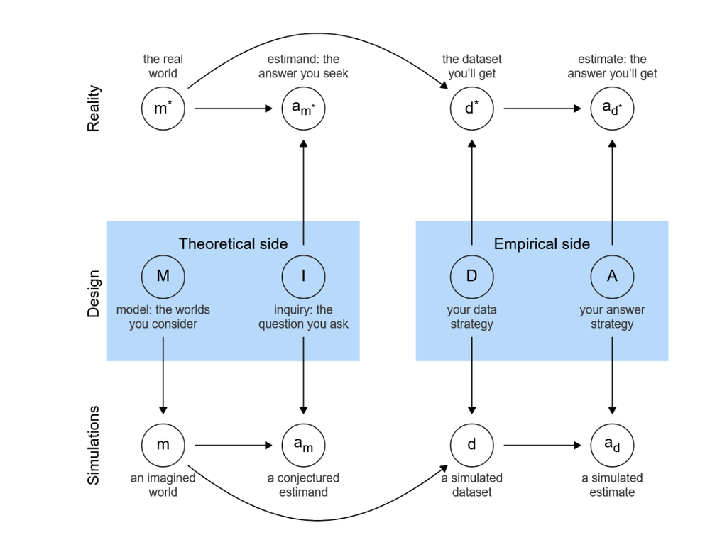

### 2.2.3 Declaration

Design declaration is telling the computer (and readers) what `M`, `I`, `D`, and `A` are.

### 2.2.4 Diagnosis

- Design diagnosis is figuring out how the design will perform under imagined conditions.
- Estimating “diagnosands” like power, bias, rmse, error rates, ethical harm, “amount learned”.
- Diagnosis takes account of model uncertainty: it aims to identify models for which the design works well and models for which it does not

### 2.2.5 Redesign

Redesign is the fine-tuning of features of the data- and answer strategies to understand how changing them affects the diagnosands

- Different sample sizes
- Different randomization procedures
- Different estimation strategies
- Implementation: effort into compliance versus more effort into sample size

### 2.2.6 Very often you have to simulate!

- Doing all this is often too hard to work out from rules of thumb or power calculators
- Specialized formulas exist for some diagnosands, but not all

## 2.3 DeclareDesign: Overview of key functions and resources

### 2.3.1 Key commands for making a design

- `declare_model()`
- `declare_inquiry()`
- `declare_sampling()`
- `declare_assignment()`
- `declare_measurement()`
- `declare_estimator()`

and there are more `declare_` functions!

### 2.3.2 Key commands for using a design

- `draw_data(design)`
- `draw_estimands(design)`
- `draw_estimates(design)`
- `get_estimates(design, data)`
- `run_design(design)`, `simulate_design(design)`
- `diagnose_design(design)`
- `redesign(design, N = 200)`
- `compare_designs()`, `compare_diagnoses()`

### 2.3.3 Pipeable commands

```r
design |>
  redesign(N = c(200, 400)) |>
  diagnose_designs() |>
  tidy() |>
  ggplot(...)
```

### 2.3.4 Cheat sheet

https://raw.githubusercontent.com/rstudio/cheatsheets/master/declaredesign.pdf

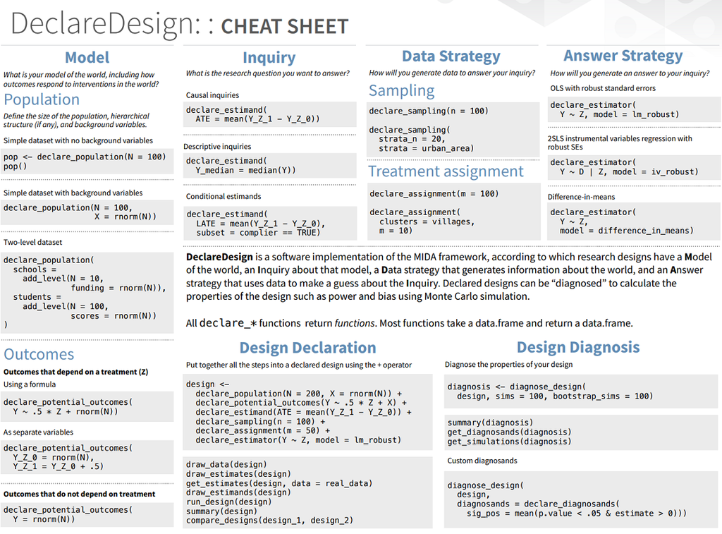

### 2.3.5 Other resources

- The website: https://declaredesign.org/
- The book: https://book.declaredesign.org
- The console: `?DeclareDesign`

## 2.4 Design declaration-diagnosis-redesign workflow: Design

### 2.4.1 The simplest possible (diagnosable) design?

```r
mean <- 0
simplest_design <-
  declare_model(N = 100, Y = rnorm(N, mean)) +
  declare_inquiry(Q = mean) +
  declare_estimator(Y ~ 1)
```

- we draw 100 units from a standard normal distribution
- we define our inquiry as the *population expectation*
- we estimate the average using a regression with a constant term

### 2.4.2 The simplest possible design?

```r
simplest_design <-
  declare_model(N = 100, Y = rnorm(N, mean)) +
  declare_inquiry(Q = 0) +
  declare_estimator(Y ~ 1)
```

- This design has three steps, with steps connected by a `+`
- The design itself is just a list of steps and has class `design`

```r
str(simplest_design)
```

```
List of 3
 $ model    :design_step:    declare_model(N = 100, Y = rnorm(N, mean))
 $ Q        :design_step:    declare_inquiry(Q = 0)
 $ estimator:design_step:    declare_estimator(Y ~ 1)
 - attr(*, "call")= language construct_design(steps = steps)
 - attr(*, "class")= chr [1:2] "design" "dd"
```

### 2.4.3 The simplest possible design? It’s a pipe

Each step is a function (or rather: a function that generates functions) and each function presupposes what is created by previous functions.

- The ordering of steps is quite important
- Most steps take the `main` data frame in and push the `main` dataframe out; this data frame normally builds up as you move along the pipe.

### 2.4.4 The simplest possible design? It’s a pipe

Each step is a function (or rather: a function that generates functions) and each function presupposes what is created by previous functions.

- The ordering of steps is quite important
- `declare_estimator` steps take the `main` data frame in and send out an `estimator_df` dataframe
- `declare_inquiry` steps take the `main` data frame in and send out an `estimand_df` dataframe.

### 2.4.5 The simplest possible design? It’s a pipe

- You can run these functions one at a time if you like.
- For instance the third step presupposes the data from the first step:

```r
df <- simplest_design[[1]]()
A  <- simplest_design[[3]](df)

A |> kable(digits = 2) |> kable_styling(font_size = 20)
```

| estimator | term | estimate | std.error | statistic | p.value | conf.low | conf.high | df | outcome |
| --- | --- | --- | --- | --- | --- | --- | --- | --- | --- |
| estimator | (Intercept) | -0.1 | 0.09 | -1.2 | 0.23 | -0.27 | 0.07 | 99 | Y |

```r
Estimand  <- simplest_design[[2]](df)

Estimand |> kable(digits = 2) |> kable_styling(font_size = 20)
```

| inquiry | estimand |
| --- | --- |
| Q | 0 |

### 2.4.6 The simplest possible design? Run it once

You can also just run through the whole design once by typing the name of the design:

```r
simplest_design
```

```
Research design declaration summary

Step 1 (model): declare_model(N = 100, Y = rnorm(N, mean)) ---------------------

Step 2 (inquiry): declare_inquiry(Q = 0) ---------------------------------------

Step 3 (estimator): declare_estimator(Y ~ 1) -----------------------------------

Run of the design:

 inquiry estimand estimator        term estimate std.error statistic p.value
       Q        0 estimator (Intercept)    0.155     0.108      1.43   0.155
 conf.low conf.high df outcome
  -0.0597     0.371 99       Y
```

### 2.4.7 The simplest possible design? Run it again

Or by asking for a run of the design

```r
one_run <- simplest_design |> run_design()
one_run |> kable(digits = 2) |> kable_styling(font_size = 18)
```

| inquiry | estimand | estimator | term | estimate | std.error | statistic | p.value | conf.low | conf.high | df | outcome |
| --- | --- | --- | --- | --- | --- | --- | --- | --- | --- | --- | --- |
| Q | 0 | estimator | (Intercept) | 0.08 | 0.1 | 0.8 | 0.43 | -0.12 | 0.28 | 99 | Y |

A single run creates data, calculates estimands (the answer to inquiries) and calculates estimates plus ancillary statistics.

### 2.4.8 The simplest possible design?: Simulation

Or by asking for a run of the design

```r
some_runs <- simplest_design |> simulate_design(sims = 1000)
some_runs |> kable(digits = 2) |> kable_styling(font_size = 16)
```

| design | sim_ID | inquiry | estimand | estimator | term | estimate | std.error | statistic | p.value | conf.low | conf.high | df | outcome |
| --- | --- | --- | --- | --- | --- | --- | --- | --- | --- | --- | --- | --- | --- |
| simplest_design | 1 | Q | 0 | estimator | (Intercept) | 0.03 | 0.09 | 0.32 | 0.75 | -0.15 | 0.21 | 99 | Y |
| simplest_design | 2 | Q | 0 | estimator | (Intercept) | 0.00 | 0.10 | 0.03 | 0.98 | -0.19 | 0.20 | 99 | Y |
| simplest_design | 3 | Q | 0 | estimator | (Intercept) | -0.13 | 0.09 | -1.46 | 0.15 | -0.31 | 0.05 | 99 | Y |
| simplest_design | 4 | Q | 0 | estimator | (Intercept) | -0.14 | 0.10 | -1.36 | 0.18 | -0.35 | 0.06 | 99 | Y |
| simplest_design | 5 | Q | 0 | estimator | (Intercept) | 0.02 | 0.12 | 0.16 | 0.88 | -0.22 | 0.26 | 99 | Y |
| simplest_design | 6 | Q | 0 | estimator | (Intercept) | -0.07 | 0.09 | -0.69 | 0.49 | -0.25 | 0.12 | 99 | Y |
| simplest_design | 7 | Q | 0 | estimator | (Intercept) | -0.09 | 0.09 | -0.99 | 0.33 | -0.28 | 0.09 | 99 | Y |
| simplest_design | 8 | Q | 0 | estimator | (Intercept) | -0.10 | 0.09 | -1.16 | 0.25 | -0.27 | 0.07 | 99 | Y |
| simplest_design | 9 | Q | 0 | estimator | (Intercept) | -0.01 | 0.10 | -0.12 | 0.90 | -0.22 | 0.19 | 99 | Y |
| simplest_design | 10 | Q | 0 | estimator | (Intercept) | 0.02 | 0.11 | 0.14 | 0.89 | -0.21 | 0.24 | 99 | Y |
| simplest_design | 11 | Q | 0 | estimator | (Intercept) | -0.06 | 0.09 | -0.70 | 0.49 | -0.25 | 0.12 | 99 | Y |
| simplest_design | 12 | Q | 0 | estimator | (Intercept) | 0.08 | 0.10 | 0.83 | 0.41 | -0.11 | 0.28 | 99 | Y |
| simplest_design | 13 | Q | 0 | estimator | (Intercept) | -0.26 | 0.10 | -2.52 | 0.01 | -0.46 | -0.06 | 99 | Y |
| simplest_design | 14 | Q | 0 | estimator | (Intercept) | 0.08 | 0.09 | 0.81 | 0.42 | -0.11 | 0.26 | 99 | Y |
| simplest_design | 15 | Q | 0 | estimator | (Intercept) | 0.07 | 0.09 | 0.72 | 0.47 | -0.12 | 0.25 | 99 | Y |
| simplest_design | 16 | Q | 0 | estimator | (Intercept) | 0.15 | 0.10 | 1.49 | 0.14 | -0.05 | 0.35 | 99 | Y |
| simplest_design | 17 | Q | 0 | estimator | (Intercept) | -0.14 | 0.09 | -1.54 | 0.13 | -0.32 | 0.04 | 99 | Y |
| simplest_design | 18 | Q | 0 | estimator | (Intercept) | -0.10 | 0.10 | -0.98 | 0.33 | -0.30 | 0.10 | 99 | Y |
| simplest_design | 19 | Q | 0 | estimator | (Intercept) | 0.06 | 0.09 | 0.62 | 0.54 | -0.13 | 0.24 | 99 | Y |
| simplest_design | 20 | Q | 0 | estimator | (Intercept) | 0.03 | 0.09 | 0.29 | 0.77 | -0.15 | 0.20 | 99 | Y |
| simplest_design | 21 | Q | 0 | estimator | (Intercept) | -0.08 | 0.09 | -0.93 | 0.35 | -0.27 | 0.10 | 99 | Y |
| simplest_design | 22 | Q | 0 | estimator | (Intercept) | -0.09 | 0.11 | -0.81 | 0.42 | -0.29 | 0.12 | 99 | Y |
| simplest_design | 23 | Q | 0 | estimator | (Intercept) | -0.11 | 0.10 | -1.06 | 0.29 | -0.31 | 0.10 | 99 | Y |
| simplest_design | 24 | Q | 0 | estimator | (Intercept) | 0.10 | 0.09 | 1.07 | 0.29 | -0.08 | 0.28 | 99 | Y |
| simplest_design | 25 | Q | 0 | estimator | (Intercept) | 0.01 | 0.09 | 0.16 | 0.88 | -0.17 | 0.20 | 99 | Y |
| simplest_design | 26 | Q | 0 | estimator | (Intercept) | -0.03 | 0.10 | -0.27 | 0.79 | -0.23 | 0.18 | 99 | Y |
| simplest_design | 27 | Q | 0 | estimator | (Intercept) | 0.22 | 0.10 | 2.17 | 0.03 | 0.02 | 0.42 | 99 | Y |
| simplest_design | 28 | Q | 0 | estimator | (Intercept) | -0.35 | 0.10 | -3.35 | 0.00 | -0.55 | -0.14 | 99 | Y |
| simplest_design | 29 | Q | 0 | estimator | (Intercept) | -0.04 | 0.09 | -0.39 | 0.69 | -0.22 | 0.15 | 99 | Y |
| simplest_design | 30 | Q | 0 | estimator | (Intercept) | 0.02 | 0.10 | 0.25 | 0.81 | -0.17 | 0.22 | 99 | Y |

[output cut: 970 more lines]

### 2.4.9 The simplest possible design?: Diagnosis

Once you have simulated many times you can “diagnose”.

This is the next topic

## 2.5 Design declaration-diagnosis-redesign workflow: Diagnosis

### 2.5.1 Diagnosis by hand

Once you have simulated many times you can “diagnose”.

For instance we can ask about bias: the average difference between the estimand and the estimate:

```r
some_runs |> mutate(error = estimate - estimand) |>
  summarize(mean_estimate = mean(estimate),
            mean_estimand = mean(estimand),
            bias = mean(error))
```

| mean_estimate | mean_estimand | bias |
| --- | --- | --- |
| 0 | 0 | 0 |

### 2.5.2 The simplest possible design?

`diagnose_design()` does this in one step for a set of common “diagnosands”:

```r
diagnosis <-
  simplest_design |>
  diagnose_design()
```

| Design | N Sims | Mean Estimand | Mean Estimate | Bias | SD Estimate | RMSE | Power | Coverage |
| --- | --- | --- | --- | --- | --- | --- | --- | --- |
| simplest_design | 500 | 0.00 | -0.00 | -0.00 | 0.10 | 0.10 | 0.05 | 0.95 |
|  |  | (0.00) | (0.00) | (0.00) | (0.00) | (0.00) | (0.01) | (0.01) |

### 2.5.3 What is the diagnosis object?

The diagnosis object is also a list; of class `diagnosis`

```r
names(diagnosis)
```

```
[1] "simulations_df"       "diagnosands_df"       "diagnosand_names"
[4] "group_by_set"         "parameters_df"        "bootstrap_replicates"
[7] "bootstrap_sims"       "duration"
```

```r
class(diagnosis)
```

```
[1] "diagnosis"
```

### 2.5.4 What is the diagnosis object?

```r
diagnosis$simulations_df |>
  head()
```

| design | sim_ID | inquiry | estimand | estimator | term | estimate | std.error | statistic | p.value | conf.low | conf.high | df | outcome |
| --- | --- | --- | --- | --- | --- | --- | --- | --- | --- | --- | --- | --- | --- |
| simplest_design | 1 | Q | 0 | estimator | (Intercept) | 0.03 | 0.09 | 0.31 | 0.76 | -0.16 | 0.21 | 99 | Y |
| simplest_design | 2 | Q | 0 | estimator | (Intercept) | 0.10 | 0.09 | 1.07 | 0.29 | -0.09 | 0.29 | 99 | Y |
| simplest_design | 3 | Q | 0 | estimator | (Intercept) | -0.16 | 0.10 | -1.54 | 0.13 | -0.37 | 0.05 | 99 | Y |
| simplest_design | 4 | Q | 0 | estimator | (Intercept) | -0.08 | 0.11 | -0.72 | 0.48 | -0.30 | 0.14 | 99 | Y |
| simplest_design | 5 | Q | 0 | estimator | (Intercept) | -0.14 | 0.10 | -1.34 | 0.18 | -0.34 | 0.07 | 99 | Y |
| simplest_design | 6 | Q | 0 | estimator | (Intercept) | -0.08 | 0.09 | -0.90 | 0.37 | -0.26 | 0.10 | 99 | Y |

### 2.5.5 What is the diagnosis object?

```r
diagnosis$diagnosands_df |>
  head()
```

| design | inquiry | estimator | outcome | term | mean_estimand | se(mean_estimand) | mean_estimate | se(mean_estimate) | bias | se(bias) | sd_estimate | se(sd_estimate) | rmse | se(rmse) | power | se(power) | coverage | se(coverage) | n_sims |
| --- | --- | --- | --- | --- | --- | --- | --- | --- | --- | --- | --- | --- | --- | --- | --- | --- | --- | --- | --- |
| simplest_design | Q | estimator | Y | (Intercept) | 0 | 0 | 0 | 0 | 0 | 0 | 0.1 | 0 | 0.1 | 0 | 0.05 | 0.01 | 0.95 | 0.01 | 500 |

### 2.5.6 What is the diagnosis object?

```r
diagnosis$bootstrap_replicates |>
  head()
```

| design | bootstrap_id | inquiry | estimator | outcome | term | mean_estimand | mean_estimate | bias | sd_estimate | rmse | power | coverage |
| --- | --- | --- | --- | --- | --- | --- | --- | --- | --- | --- | --- | --- |
| simplest_design | 1 | Q | estimator | Y | (Intercept) | 0 | 0.00 | 0.00 | 0.1 | 0.10 | 0.05 | 0.95 |
| simplest_design | 2 | Q | estimator | Y | (Intercept) | 0 | -0.01 | -0.01 | 0.1 | 0.11 | 0.06 | 0.94 |
| simplest_design | 3 | Q | estimator | Y | (Intercept) | 0 | -0.01 | -0.01 | 0.1 | 0.10 | 0.05 | 0.95 |
| simplest_design | 4 | Q | estimator | Y | (Intercept) | 0 | -0.01 | -0.01 | 0.1 | 0.10 | 0.05 | 0.95 |
| simplest_design | 5 | Q | estimator | Y | (Intercept) | 0 | 0.00 | 0.00 | 0.1 | 0.10 | 0.05 | 0.95 |
| simplest_design | 6 | Q | estimator | Y | (Intercept) | 0 | 0.00 | 0.00 | 0.1 | 0.10 | 0.05 | 0.95 |

### 2.5.7 Diagnosis: Bootstraps

- The bootstraps dataframe is produced by resampling from the simulations dataframe and producing a diagnosis dataframe from each resampling.
- This lets us generate estimates of uncertainty around our diagnosands.
- It can be controlled thus:

```r
diagnose_design(
  ...,
  bootstrap_sims = 100
)
```

### 2.5.8 After Diagnosis

It’s reshapeable: as a tidy dataframe, ready for graphing

```r
diagnosis |>
  tidy()
```

| design | inquiry | estimator | outcome | term | diagnosand | estimate | std.error | conf.low | conf.high |
| --- | --- | --- | --- | --- | --- | --- | --- | --- | --- |
| simplest_design | Q | estimator | Y | (Intercept) | mean_estimand | 0.00 | 0.00 | 0.00 | 0.00 |
| simplest_design | Q | estimator | Y | (Intercept) | mean_estimate | 0.00 | 0.00 | -0.01 | 0.00 |
| simplest_design | Q | estimator | Y | (Intercept) | bias | 0.00 | 0.00 | -0.01 | 0.00 |
| simplest_design | Q | estimator | Y | (Intercept) | sd_estimate | 0.10 | 0.00 | 0.10 | 0.11 |
| simplest_design | Q | estimator | Y | (Intercept) | rmse | 0.10 | 0.00 | 0.10 | 0.11 |
| simplest_design | Q | estimator | Y | (Intercept) | power | 0.05 | 0.01 | 0.03 | 0.07 |
| simplest_design | Q | estimator | Y | (Intercept) | coverage | 0.95 | 0.01 | 0.93 | 0.97 |

### 2.5.9 After Diagnosis

It’s reshapeable: as a tidy dataframe, ready for graphing

```r
diagnosis |>
  tidy() |>
  ggplot(aes(estimate, diagnosand)) + geom_point() +
  geom_errorbarh(aes(xmax = conf.high, xmin = conf.low, height = .2))
```

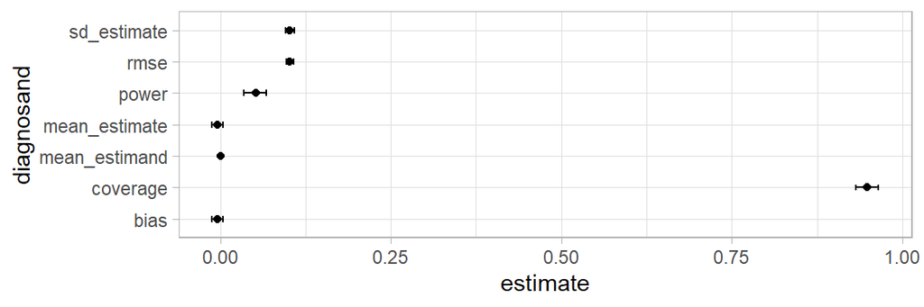

### 2.5.10 After Diagnosis: Tables

Or turn into a formatted table:

```r
diagnosis |>
  reshape_diagnosis()
```

| Design | Inquiry | Estimator | Outcome | Term | N Sims | Mean Estimand | Mean Estimate | Bias | SD Estimate | RMSE | Power | Coverage |
| --- | --- | --- | --- | --- | --- | --- | --- | --- | --- | --- | --- | --- |
| simplest_design | Q | estimator | Y | (Intercept) | 500 | 0.00 | -0.00 | -0.00 | 0.10 | 0.10 | 0.05 | 0.95 |
|  |  |  |  |  |  | (0.00) | (0.00) | (0.00) | (0.00) | (0.00) | (0.01) | (0.01) |

### 2.5.11 Advanced Diagnosis: Variations

```r
DeclareDesign:::default_diagnosands
```

```r
    mean_estimand <- mean(estimand)
    mean_estimate <- mean(estimate)
    bias <- mean(estimate - estimand)
    sd_estimate <- sd(estimate)
    rmse <- sqrt(mean((estimate - estimand)^2))
    power <- mean(p.value <= alpha)
    coverage <- mean(estimand <= conf.high & estimand >= conf.low)
```

### 2.5.12 Advanced Diagnosis: Other diagnosands

```r
    mean_se = mean(std.error)
    type_s_rate = mean((sign(estimate) != sign(estimand))[p.value <= alpha])
    exaggeration_ratio = mean((estimate/estimand)[p.value <= alpha])
    var_estimate = pop.var(estimate)
    mean_var_hat = mean(std.error^2)
    prop_pos_sig = estimate > 0 & p.value <= alpha
    mean_ci_length = mean(conf.high - conf.low)
```

### 2.5.13 Advanced Diagnosis: Custom diagnosands

```r
my_diagnosands <-
  declare_diagnosands(median_bias = median(estimate - estimand))

diagnose_design(simplest_design, diagnosands = my_diagnosands, sims = 10) |>
  reshape_diagnosis() |> kable() |> kable_styling(font_size = 20)
```

| Design | Inquiry | Estimator | Outcome | Term | N Sims | Median Bias |
| --- | --- | --- | --- | --- | --- | --- |
| simplest_design | Q | estimator | Y | (Intercept) | 10 | -0.04 |
|  |  |  |  |  |  | (0.04) |

### 2.5.14 Advanced Diagnosis: Adding diagnosands to a design

```r
simplest_design <-
  set_diagnosands(simplest_design, my_diagnosands)

simplest_design |> diagnose_design(sims = 10)|>
  reshape_diagnosis() |> kable() |> kable_styling(font_size = 20)
```

| Design | Inquiry | Estimator | Outcome | Term | N Sims | Median Bias |
| --- | --- | --- | --- | --- | --- | --- |
| simplest_design | Q | estimator | Y | (Intercept) | 10 | 0.03 |
|  |  |  |  |  |  | (0.03) |

### 2.5.15 Advanced Diagnosis: Diagnosing multiple designs

You can diagnose multiple designs or a list of designs

```r
list(dum = simplest_design, dee = simplest_design) |>
  diagnose_design(sims = 5) |>
  reshape_diagnosis() |>
  kable() |>
  kable_styling(font_size = 20)
```

| Design | Inquiry | Estimator | Outcome | Term | N Sims | Median Bias |
| --- | --- | --- | --- | --- | --- | --- |
| dum | Q | estimator | Y | (Intercept) | 5 | 0.02 |
|  |  |  |  |  |  | (0.08) |
| dee | Q | estimator | Y | (Intercept) | 5 | -0.03 |
|  |  |  |  |  |  | (0.04) |

### 2.5.16 Advanced Diagnosis: Diagnosing in groups

You can partition the simulations data frame into groups before calculating diagnosands.

```r
grouped_diagnosis <-

  simplest_design |>
  diagnose_design(
    make_groups = vars(significant = p.value <= 0.05),
    sims = 500
  )
```

| Design | Significant | N Sims | Mean Estimand | Mean Estimate | Bias | SD Estimate | RMSE | Power | Coverage |
| --- | --- | --- | --- | --- | --- | --- | --- | --- | --- |
| design_1 | FALSE | 474 | 0.00 | -0.00 | -0.00 | 0.09 | 0.09 | 0.00 | 1.00 |
|  |  |  | (0.00) | (0.00) | (0.00) | (0.00) | (0.00) | (0.00) | (0.00) |
| design_1 | TRUE | 26 | 0.00 | -0.02 | -0.02 | 0.23 | 0.23 | 1.00 | 0.00 |
|  |  |  | (0.00) | (0.04) | (0.04) | (0.01) | (0.01) | (0.00) | (0.00) |

Note especially the mean estimate, the power, the coverage, the RMSE, and the bias. (Bias is not large because we have both under and over estimates)

### 2.5.17 Significance filter

```r
grouped_diagnosis$simulations_df |>
  ggplot(aes(estimate, p.value, color = significant)) + geom_point()
```

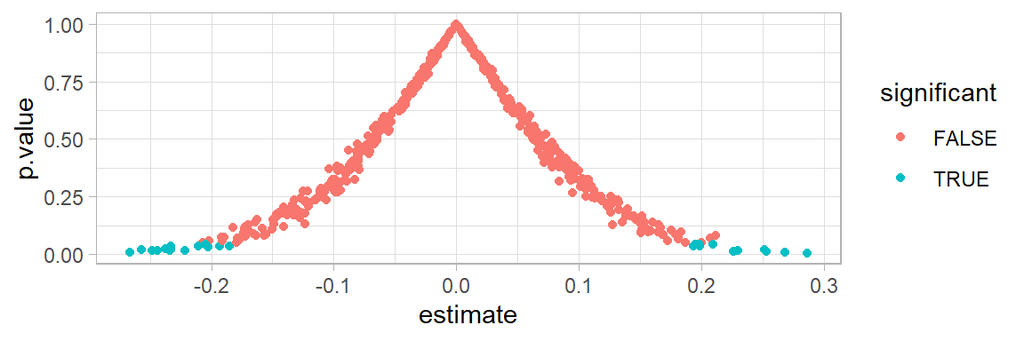

### 2.5.18 Advanced Diagnosis: Multistage simulation

- Usually a design simulation simulates “from the top”: going from the beginning to the end of the design in each run and repeating
- But sometimes you might want to follow a tree like structure and simulate different steps a different number of times

### 2.5.19 Advanced Diagnosis: Multistage simulation

Consider for instance this sampling design:

```r
sampling_design <-

  declare_model(N = 500, Y = 1 + rnorm(N, sd = 10)) +
  declare_inquiry(Q = mean(Y)) +
  declare_sampling(S = complete_rs(N = N, n = 100)) +
  declare_estimator(Y ~ 1)
```

### 2.5.20 Advanced Diagnosis: Multistage simulation

Compare these two diagnoses:

```r
diagnosis_1 <- diagnose_design(sampling_design, sims = c(5000, 1, 1, 1))
diagnosis_2 <- diagnose_design(sampling_design, sims = c(1, 5000, 1, 1))
```

| diagnosis | N Sims | Mean Estimand | Mean Estimate | Bias | SD Estimate | RMSE | Power | Coverage |
| --- | --- | --- | --- | --- | --- | --- | --- | --- |
| diagnosis_1 | 5000 | 1.00 | 1.00 | -0.00 | 1.01 | 0.90 | 0.17 | 0.97 |
| diagnosis_1 |  | (0.01) | (0.01) | (0.01) | (0.01) | (0.01) | (0.01) | (0.00) |
| diagnosis_2 | 5000 | 1.22 | 1.22 | -0.00 | 0.91 | 0.91 | 0.20 | 0.97 |
| diagnosis_2 |  | (0.00) | (0.00) | (0.00) | (0.00) | (0.00) | (0.00) | (0.00) |

### 2.5.21 Spotting design problems with diagnosis

Diagnosis alerts to problems in a design. Consider the following simple alternative design.

```r
simplest_design_2 <-

  declare_model(N = 100, Y = rnorm(N)) +
  declare_inquiry(Q = mean(Y)) +
  declare_estimator(Y ~ 1)
```

Here we define the inquiry as the sample average $Y$ (instead of the population mean). But otherwise things stay the same.

What do we think of this design?

### 2.5.22 Spotting design problems with diagnosis

Here is the diagnosis

| Design | N Sims | Mean Estimand | Mean Estimate | Bias | SD Estimate | RMSE | Power | Coverage |
| --- | --- | --- | --- | --- | --- | --- | --- | --- |
| simplest_design_2 | 500 | -0.00 | -0.00 | 0.00 | 0.10 | 0.00 | 0.04 | 1.00 |
|  |  | (0.00) | (0.00) | (0.00) | (0.00) | (0.00) | (0.01) | (0.00) |

- Why is coverage so high? is that OK?
- Why is the RMSE 0 but the SD of the estimate > 0? is that OK?
  - Is it because the RMSE is too low?
  - Or the standard error is too large?

### 2.5.23 It depends on the inquiry

- If we are really interested in the sample average then our standard error is off: *we should have no error at all!*
- If we are really interested in the population average then our inquiry is badly defined: *it should not be redefined on each run!*

## 2.6 Design declaration-diagnosis-redesign workflow: Redesign

### 2.6.1 Redesign

Redesign is the process of taking a design and modifying it in some way.

There are a few ways to do this:

1. Just make a new design using modified code
2. Take a design and alter some steps using `replace_step`, `insert_step` or `delete_step`
3. Modify a design *parameter* using `redesign`

we will focus on the third approach

### 2.6.2 Redesign

- A design parameter is a modifiable quantity of a design.
- These quantities are objects that were in your global environment when you made your design, get referred to explicitly in your design, and got scooped up when the design was formed.
- In our simplest design above we had a fixed `N`, but we could make `N` a modifiable quantity like this:

```r
N <- 100

simplest_design_N <-

  declare_model(N = N, Y = rnorm(N)) +
  declare_inquiry(Q = 0) +
  declare_estimator(Y ~ 1)
```

### 2.6.3 Redesign

```r
N <- 100

simplest_design_N <-

  declare_model(N = N, Y = rnorm(N)) +
  declare_inquiry(Q = 0) +
  declare_estimator(Y ~ 1)
```

Note that `N` is defined in memory; and it gets called in one of the steps. It has now become a parameter of the design and it can be modified using redesign.

### 2.6.4 Simple Redesign

Here is a version of the design with `N = 200`:

```r
design_200 <- simplest_design_N |> redesign(N = 200)

design_200 |> draw_data() |> nrow()
```

```
[1] 200
```

### 2.6.5 Redesigning to a list

Here is a list of three different designs with different *N*s.

```r
design_Ns <- simplest_design_N |> redesign(N = c(200, 400, 800))

design_Ns |> lapply(draw_data) |> lapply(nrow)
```

```
$design_1
[1] 200

$design_2
[1] 400

$design_3
[1] 800
```

### 2.6.6 Redesigning to a list

The good thing here is that it is now easy to diagnose over multiple designs and compare diagnoses. The parameter names then end up in the `diagnosis_df`

Consider this:

```r
N <- 100
m <- 0

design <-
  declare_model(N = N, Y = rnorm(N, m)) +
  declare_inquiry(Q = m) +
  declare_estimator(Y ~ 1)
```

Then:

```r
designs <-  redesign(design, N = c(100, 200, 300), m = c(0, .1, .2))

designs |> diagnose_design() |> tidy()
```

### 2.6.7 Redesigning to a list

Output:

```r
designs |> diagnose_design() |> tidy()
```

| N | m | diagnosand | estimate | std.error | conf.low | conf.high |
| --- | --- | --- | --- | --- | --- | --- |
| 100 | 0.0 | mean_estimand | 0.00 | 0.00 | 0.00 | 0.00 |
| 100 | 0.0 | mean_estimate | 0.00 | 0.00 | -0.01 | 0.01 |
| 100 | 0.0 | bias | 0.00 | 0.00 | -0.01 | 0.01 |
| 100 | 0.0 | sd_estimate | 0.10 | 0.00 | 0.10 | 0.11 |
| 200 | 0.0 | mean_estimand | 0.00 | 0.00 | 0.00 | 0.00 |
| 200 | 0.0 | mean_estimate | 0.00 | 0.00 | -0.01 | 0.00 |
| 200 | 0.1 | mean_estimand | 0.10 | 0.00 | 0.10 | 0.10 |
| 200 | 0.1 | mean_estimate | 0.10 | 0.00 | 0.09 | 0.10 |
| 300 | 0.2 | bias | 0.00 | 0.00 | 0.00 | 0.00 |
| 300 | 0.2 | sd_estimate | 0.06 | 0.00 | 0.05 | 0.06 |
| 300 | 0.2 | rmse | 0.06 | 0.00 | 0.05 | 0.06 |
| 300 | 0.2 | power | 0.93 | 0.01 | 0.91 | 0.95 |
| 300 | 0.2 | coverage | 0.95 | 0.01 | 0.92 | 0.97 |

### 2.6.8 Redesigning to a list

Graphing after redesign is especially easy:

```r
designs |> diagnose_design() |>
  tidy() |>
  filter(diagnosand %in% c("power", "rmse")) |>
  ggplot(aes(N, estimate, color = factor(m))) +
  geom_line() +
  facet_wrap(~diagnosand)
```

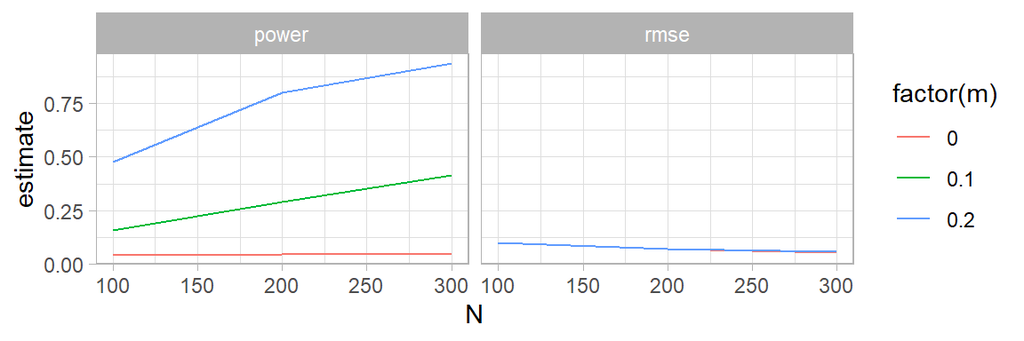

Power depends on N and m, rmse depends on N only

### 2.6.9 Redesign with vector arguments

When redesigning with arguments that are vectors, use `list()` in redesign, with each list item representing a design you wish to create

```r
prob_each <- c(.1, .5, .4)

design_multi  <-
  declare_model(N = 10) +
  declare_assignment(Z = complete_ra(N = N, prob_each = prob_each))

## returns two designs

designs <- design_multi |>
  redesign(prob_each = list(c(.2, .5, .3), c(0, .5, .5)))

designs |> lapply(draw_data)
```

### 2.6.10 Redesign warnings

A parameter has to be called correctly. And you get no warning if you misname.

```r
simplest_design_N  |> redesign(n = 200) |> draw_data() |> nrow()
```

```
[1] 100
```

why not 200?

### 2.6.11 Redesign warnings

A parameter has to be called explicitly

```r
N <- 100

my_N <- function(n = N) n

simplest_design_N2 <-

  declare_model(N = my_N(), Y = rnorm(N)) +
  declare_inquiry(Q = 0) +
  declare_estimator(Y ~ 1)

simplest_design_N2 |> redesign(N = 200) |> draw_data() |> nrow()
```

```
[1] 100
```

why not 200?

### 2.6.12 Redesign warnings

A parameter has to be called explicitly

```r
N <- 100

my_N <- function(n = N) n

simplest_design_N2 <-

  declare_model(N = my_N(N), Y = rnorm(N)) +
  declare_inquiry(Q = 0) +
  declare_estimator(Y ~ 1)

simplest_design_N2 |> redesign(N = 200) |> draw_data() |> nrow()
```

```
[1] 200
```

OK

### 2.6.13 Redesign with a function

Here is an example of redesigning where the “parameter” is a function

```r
new_N <- function(n, factor = 1.31) n*factor

simplest_design_N2 |> redesign(my_N = new_N) |> draw_data() |> nrow()
```

```
[1] 131
```

## 2.7 Using a design

What can you do with a design once you have it?

We will start with a very simple experimental design (more on the components of this later)

```r
b <-1
N <- 100
design <-
  declare_model(N = N, U = rnorm(N), potential_outcomes(Y ~ b * Z + U)) +
  declare_assignment(Z = simple_ra(N), Y = reveal_outcomes(Y ~ Z)) +
  declare_inquiry(ate = mean(Y_Z_1 - Y_Z_0)) +
  declare_estimator(Y ~ Z, inquiry = "ate", .method = lm_robust)
```

### 2.7.1 Make data from the design

```r
data <- draw_data(design)

data |> head () |> kable() |> kable_styling(font_size = 20)
```

| ID | U | Y_Z_0 | Y_Z_1 | Z | Y |
| --- | --- | --- | --- | --- | --- |
| 001 | 0.8939241 | 0.8939241 | 1.8939241 | 1 | 1.8939241 |
| 002 | 1.3350334 | 1.3350334 | 2.3350334 | 1 | 2.3350334 |
| 003 | 0.8329075 | 0.8329075 | 1.8329075 | 1 | 1.8329075 |
| 004 | -0.2886946 | -0.2886946 | 0.7113054 | 0 | -0.2886946 |
| 005 | -0.3062044 | -0.3062044 | 0.6937956 | 1 | 0.6937956 |
| 006 | 0.6443779 | 0.6443779 | 1.6443779 | 1 | 1.6443779 |

### 2.7.2 Make data from the design

Play with the data:

```r
lm_robust(Y ~ Z, data = data) |>
  tidy() |>
  kable(digits = 2) |>
  kable_styling(font_size = 20)
```

| term | estimate | std.error | statistic | p.value | conf.low | conf.high | df | outcome |
| --- | --- | --- | --- | --- | --- | --- | --- | --- |
| (Intercept) | -0.21 | 0.14 | -1.50 | 0.14 | -0.48 | 0.07 | 98 | Y |
| Z | 1.27 | 0.19 | 6.69 | 0.00 | 0.89 | 1.65 | 98 | Y |

### 2.7.3 Draw estimands

```r
draw_estimands(design) |>
  kable(digits = 2) |>
  kable_styling(font_size = 20)
```

| inquiry | estimand |
| --- | --- |
| ate | 1 |

### 2.7.4 Draw estimates

```r
draw_estimates(design) |>
  kable(digits = 2) |>
  kable_styling(font_size = 20)
```

| estimator | term | estimate | std.error | statistic | p.value | conf.low | conf.high | df | outcome | inquiry |
| --- | --- | --- | --- | --- | --- | --- | --- | --- | --- | --- |
| estimator | Z | 1.06 | 0.19 | 5.57 | 0 | 0.69 | 1.44 | 98 | Y | ate |

### 2.7.5 Get estimates

Using your actual data:

```r
get_estimates(design, data) |>
  kable(digits = 2) |>
  kable_styling(font_size = 20)
```

| estimator | term | estimate | std.error | statistic | p.value | conf.low | conf.high | df | outcome | inquiry |
| --- | --- | --- | --- | --- | --- | --- | --- | --- | --- | --- |
| estimator | Z | 1.27 | 0.19 | 6.69 | 0 | 0.89 | 1.65 | 98 | Y | ate |

### 2.7.6 Simulate design

```r
simulate_design(design, sims = 3) |>
  kable(digits = 2) |>
  kable_styling(font_size = 16)
```

| design | sim_ID | inquiry | estimand | estimator | term | estimate | std.error | statistic | p.value | conf.low | conf.high | df | outcome |
| --- | --- | --- | --- | --- | --- | --- | --- | --- | --- | --- | --- | --- | --- |
| design | 1 | ate | 1 | estimator | Z | 1.13 | 0.19 | 5.99 | 0 | 0.76 | 1.51 | 98 | Y |
| design | 2 | ate | 1 | estimator | Z | 1.18 | 0.20 | 5.88 | 0 | 0.78 | 1.57 | 98 | Y |
| design | 3 | ate | 1 | estimator | Z | 1.21 | 0.19 | 6.21 | 0 | 0.82 | 1.60 | 98 | Y |

### 2.7.7 Diagnose design

```r
design |>
  diagnose_design(sims = 100)
```

| Mean Estimate | Bias | SD Estimate | RMSE | Power | Coverage |
| --- | --- | --- | --- | --- | --- |
| 0.99 | -0.01 | 0.20 | 0.20 | 1.00 | 0.95 |
| (0.02) | (0.02) | (0.02) | (0.02) | (0.00) | (0.02) |

### 2.7.8 Redesign

```r
new_design <-

  design |> redesign(b = 0)
```

- Modify any arguments that are explicitly called on by design steps.
- Or add, remove, or replace steps

### 2.7.9 Compare designs

```r
redesign(design, N = 50) %>%

  compare_diagnoses(design)
```

| diagnosand | mean_1 | mean_2 | mean_difference | conf.low | conf.high |
| --- | --- | --- | --- | --- | --- |
| mean_estimand | 0.50 | 0.50 | 0.00 | 0.00 | 0.00 |
| mean_estimate | 0.48 | 0.50 | 0.02 | -0.01 | 0.04 |
| bias | -0.02 | 0.00 | 0.02 | -0.01 | 0.04 |
| sd_estimate | 0.28 | 0.20 | -0.08 | -0.10 | -0.06 |
| rmse | 0.28 | 0.20 | -0.08 | -0.10 | -0.06 |
| power | 0.38 | 0.71 | 0.32 | 0.26 | 0.37 |
| coverage | 0.97 | 0.96 | -0.01 | -0.04 | 0.01 |

### 2.7.10 Illustration of power calculation

Recall?: The power of a design is the *probability* that you will reject a null hypothesis

```r
N <- 100
b <- .5

design <-
  declare_model(N = N,
    U = rnorm(N),
    potential_outcomes(Y ~ b * Z + U)) +
  declare_assignment(Z = simple_ra(N),
                     Y = reveal_outcomes(Y ~ Z)) +
  declare_inquiry(ate = mean(Y_Z_1 - Y_Z_0)) +
  declare_estimator(Y ~ Z, inquiry = "ate", .method = lm_robust)
```

### 2.7.11 “Run” the design once

```r
run_design(design)
```

Summary of a single 'run' of the design

| inquiry | estimand | estimator | term | estimate | std.error | statistic | p.value | conf.low | conf.high | df | outcome |
| --- | --- | --- | --- | --- | --- | --- | --- | --- | --- | --- | --- |
| ate | 0.5 | estimator | Z | 0.28 | 0.2 | 1.39 | 0.17 | -0.12 | 0.69 | 98 | Y |

### 2.7.12 Run it many times

```r
sims_1 <- simulate_design(design)

sims_1 |> select(sim_ID, estimate, p.value)
```

| sim_ID | estimate | p.value |
| --- | --- | --- |
| 1 | 0.81 | 0.00 |
| 2 | 0.40 | 0.04 |
| 3 | 0.88 | 0.00 |
| 4 | 0.72 | 0.00 |
| 5 | 0.38 | 0.05 |
| 6 | 0.44 | 0.02 |

### 2.7.13 Power is mass of the sampling distribution *of decisions* under the model

```r
sims_1 |>
  ggplot(aes(p.value)) +
  geom_histogram(boundary = 0) +
  geom_vline(xintercept = .05, color = "red")
```

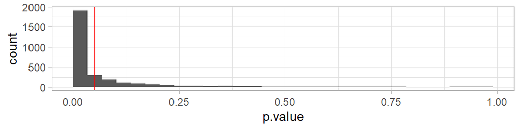

### 2.7.14 Power is mass of the sampling distribution *of decisions* under the model

```r
redesign(design, b = 0) |>
  simulate_design(sims = 10000)
```

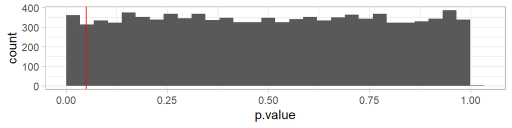

### 2.7.15 Design diagnosis does it all (over multiple designs)

```r
  diagnose_design(design)
```

| Mean Estimate | Bias | SD Estimate | RMSE | Power | Coverage |
| --- | --- | --- | --- | --- | --- |
| 0.50 | 0.00 | 0.20 | 0.20 | 0.70 | 0.95 |
| (0.00) | (0.00) | (0.00) | (0.00) | (0.00) | (0.00) |

### 2.7.16 Design diagnosis does it all

```r
design |>
  redesign(b = c(0, 0.25, 0.5, 1)) |>
  diagnose_design()
```

| b | Mean Estimate | Bias | SD Estimate | RMSE | Power | Coverage |
| --- | --- | --- | --- | --- | --- | --- |
| 0 | -0.00 | -0.00 | 0.20 | 0.20 | 0.05 | 0.95 |
|  | (0.00) | (0.00) | (0.00) | (0.00) | (0.00) | (0.00) |
| 0.25 | 0.25 | -0.00 | 0.20 | 0.20 | 0.23 | 0.95 |
|  | (0.00) | (0.00) | (0.00) | (0.00) | (0.00) | (0.00) |
| 0.5 | 0.50 | 0.00 | 0.20 | 0.20 | 0.70 | 0.95 |
|  | (0.00) | (0.00) | (0.00) | (0.00) | (0.00) | (0.00) |
| 1 | 1.00 | 0.00 | 0.20 | 0.20 | 1.00 | 0.95 |
|  | (0.00) | (0.00) | (0.00) | (0.00) | (0.00) | (0.00) |

## 2.8 Declaration: a deeper dive (Reference)

We start with a simple experimental design and then show ways to extend.

- Variations to *M* and *I* are supported by the `fabricatr` package (and others)
- Variations to *D* are supported by the `randomizr` package (and others)
- Variations to *A* are supported by the `estimatr` package (and others)

### 2.8.1 Steps: A simple experimental design

```r
N <- 100
b <- .5

design <-
  declare_model(N = N, U = rnorm(N),
                potential_outcomes(Y ~ b * Z + U)) +
  declare_assignment(Z = simple_ra(N), Y = reveal_outcomes(Y ~ Z)) +
  declare_inquiry(ate = mean(Y_Z_1 - Y_Z_0)) +
  declare_estimator(Y ~ Z, inquiry = "ate", .method = lm_robust)
```

A few new elements here:

- `declare_model` can be used much like `mutate` with multiple columns created in sequence
- the `potential_outcomes` function is a special function that creates potential outcome columns
- when you assign a treatment that affects an outcome you can use `reveal_outcome` to reveal the outcome; `Z` and `Y` are default

### 2.8.2 Steps: A simple experimental design

```r
N <- 100
b <- .5

design <-
  declare_model(N = N, U = rnorm(N),
                potential_outcomes(Y ~ b * Z + U)) +
  declare_assignment(Z = simple_ra(N), Y = reveal_outcomes(Y ~ Z)) +
  declare_inquiry(ate = mean(Y_Z_1 - Y_Z_0)) +
  declare_estimator(Y ~ Z,
                    inquiry = "ate",
                    .method = lm_robust,
                    label = "estimator 1")
```

A few new elements here:

- when you declare an estimator you should normally associate an inquiry with the estimator and provide the method to be used; `lm_robust` is default
- you should generally label estimators as you may have many

### 2.8.3 Steps: Order matters

e.g. If you sample before defining the inquiry you get a different inquiry to if you sample after you define the inquiry

```r
design_1 <-
  declare_model(N = 1000, X = rep(0:1, N/2), Y = X + rnorm(N)) +
  declare_sampling(S= strata_rs(strata = X, strata_prob = c(.2, .8))) +
  declare_inquiry(m = mean(Y))

design_1 |> draw_estimands()
```

```
  inquiry  estimand
1       m 0.7907839
```

### 2.8.4 Steps: Order matters

e.g. If you sample before defining the inquiry you get a different inquiry to if you sample after you define the inquiry

```r
design_2 <-
  declare_model(N = 1000, X = rep(0:1, N/2), Y = X + rnorm(N)) +
  declare_inquiry(m = mean(Y)) +
  declare_sampling(S= strata_rs(strata = X, strata_prob = c(.2, .8)))

design_2 |> draw_estimands()
```

```
  inquiry  estimand
1       m 0.5467558
```

### 2.8.5 M: Key extensions to model declaration

You can generate hierarchical data like this:

```r
M <-
  declare_model(
    households = add_level(
      N = 100,
      N_members = sample(c(1, 2, 3, 4), N,
                         prob = c(0.2, 0.3, 0.25, 0.25), replace = TRUE)
    ),
    individuals = add_level(
      N = N_members,
      age = sample(18:90, N, replace = TRUE)
    )
  )
```

### 2.8.6 M: Key extensions to model declaration

You can generate hierarchical data like this:

```r
M() |> head() |> kable(digits = 2) |> kable_styling(font_size = 20)
```

| households | N_members | individuals | age |
| --- | --- | --- | --- |
| 001 | 1 | 001 | 57 |
| 002 | 4 | 002 | 34 |
| 002 | 4 | 003 | 40 |
| 002 | 4 | 004 | 57 |
| 002 | 4 | 005 | 31 |
| 003 | 3 | 006 | 41 |

### 2.8.7 M: Key extensions to model declaration

You can generate panel data like this:

```r
M <-
  declare_model(
    countries = add_level(
      N = 196,
      country_shock = rnorm(N)
    ),
    years = add_level(
      N = 100,
      time_trend = 1:N,
      year_shock = runif(N, 1, 10),
      nest = FALSE
    ),
    observation = cross_levels(
      by = join_using(countries, years),
      observation_shock = rnorm(N),
      Y = 0.01 * time_trend + country_shock + year_shock + observation_shock
    )
  )
```

### 2.8.8 M: Key extensions to model declaration

You can generate panel data like this:

```r
M() |> head() |> kable(digits = 2) |> kable_styling(font_size = 20)
```

| countries | country_shock | years | time_trend | year_shock | observation | observation_shock | Y |
| --- | --- | --- | --- | --- | --- | --- | --- |
| 001 | -1.01 | 001 | 1 | 7.24 | 00001 | 0.14 | 6.38 |
| 002 | 1.59 | 001 | 1 | 7.24 | 00002 | 1.10 | 9.94 |
| 003 | 0.18 | 001 | 1 | 7.24 | 00003 | 0.94 | 8.37 |
| 004 | -2.07 | 001 | 1 | 7.24 | 00004 | 0.21 | 5.40 |
| 005 | 0.22 | 001 | 1 | 7.24 | 00005 | 1.08 | 8.55 |
| 006 | -0.37 | 001 | 1 | 7.24 | 00006 | 1.22 | 8.11 |

### 2.8.9 M: You can pull in preexisting data

```r
M <-
  declare_model(
    data = baseline_data,
    attitudes = sample(1:5, N, replace = TRUE)
  )
```

### 2.8.10 M: A simple experimental design

You can repeat steps and play with the order, always conscious of the direction of the pipe

```r
design <-
  declare_model(N = N, X = rep(0:1, N/2)) +
  declare_model(U = rnorm(N), potential_outcomes(Y ~ b * Z * X + U)) +
  declare_assignment(Z = block_ra(blocks = X), Y = reveal_outcomes(Y ~ Z)) +
  declare_inquiry(ate = mean(Y_Z_1 - Y_Z_0)) +
  declare_inquiry(cate = mean(Y_Z_1[X==0] - Y_Z_0[X==0])) +
  declare_estimator(Y ~ Z, inquiry = "ate", label = "ols") +
  declare_estimator(Y ~ Z*X, inquiry = "cate", label = "fe")
```

### 2.8.11 M: You can generate multiple columns together

```r
M2 <-
  declare_model(
    draw_multivariate(c(X1, X2) ~ MASS::mvrnorm(
      n = 1000,
      mu = c(0, 0),
      Sigma = matrix(c(1, 0.3, 0.3, 1), nrow = 2)
    )))
```

### 2.8.12 M: You can generate multiple columns together

```r
M2() |> head() |> kable(digits = 2) |> kable_styling(font_size = 28)
```

| X1 | X2 |
| --- | --- |
| -1.37 | -0.97 |
| 1.33 | -0.04 |
| -0.56 | 1.33 |
| 0.29 | -1.29 |
| 0.41 | -0.58 |
| -1.22 | -1.16 |

### 2.8.13 M: Cluster structures with cluster correlations

```r
M <-
  declare_model(households = add_level(N = 1000),
                individuals = add_level(
                  N = 4,
                  X = draw_normal_icc(
                    mean = 0,
                    clusters = households,
                    ICC = 0.65
                  )
                ))
```

### 2.8.14 M: Cluster structures with cluster correlations

```r
model <- lm_robust(X ~ households, data = M())
model$adj.r.squared
```

```
[1] 0.6709427
```

### 2.8.15 I: Inquiries

Many causal inquiries are simple summaries of potential outcomes:

| Inquiry | Units | Code |
| --- | --- | --- |
| Average treatment effect in a finite population (PATE) | Units in the population | `mean(Y_D_1 - Y_D_0)` |
| Conditional average treatment effect (CATE) for X = 1 | Units for whom X = 1 | `mean(Y_D_1[X == 1] - Y_D_0[X == 1])` |
| Complier average causal effect (CACE) | Complier units | `mean(Y_D_1[D_Z_1 > D_Z_0] - Y_D_0[D_Z_1 > D_Z_0])` |
| Causal interactions of $D_1$ and $D_2$ | Units in the population | `mean((Y_D1_1_D2_1 - Y_D1_0_D2_1) - (Y_D1_1_D2_0 - Y_D1_0_D2_0))` |

Generating potential outcomes columns gets you far

### 2.8.16 I: Inquiries

Often though we need to define inquiries as a function of continuous variables. For this generating a potential outcomes function can make life easier. This helps for:

- Continuous quantities
- Spillover quantities
- Complex counterfactuals

### 2.8.17 I: Inquiries: Complex counterfactuals

Here is an example of using functions to define complex counterfactuals:

```r
f_M <- function(X, UM) 1*(UM < X)
f_Y <- function(X, M, UY) X + M - .4*X*M + UY

design <-
  declare_model(N = 100,
                X = simple_rs(N),
                UM = runif(N),
                UY = rnorm(N),
                M = f_M(X, UM),
                Y = f_Y(X, M, UY)) +
  declare_inquiry(Q1 = mean(f_Y(1, f_M(0, UM), UY) - f_Y(0, f_M(0, UM), UY)))

design |> draw_estimands() |> kable() |> kable_styling(font_size = 20)
```

| inquiry | estimand |
| --- | --- |
| Q1 | 1 |

### 2.8.18 I: Inquiries: Complex counterfactuals

Here is an example of using functions to define effects of continuous treatments.

```r
f_Y <- function(X, UY) X - .25*X^2 + UY

design <-
  declare_model(N = 100,
                X  = rnorm(N),
                UY = rnorm(N),
                Y = f_Y(X, UY)) +
  declare_inquiry(
    Q1 = mean(f_Y(X+1, UY) - f_Y(X, UY)),
    Q2 = mean(f_Y(1, UY) - f_Y(0, UY)),
    Q3 = (lm_robust(Y ~ X)|> tidy())[2,2]
    )

design |> draw_estimands() |> kable() |> kable_styling(font_size = 20)
```

| inquiry | estimand |
| --- | --- |
| Q1 | 0.857143 |
| Q2 | 0.750000 |
| Q3 | 1.363886 |

which one is the ATE?

### 2.8.19 D: Assignment schemes

The `randomizr` package has a set of functions for different types of block and cluster assignments.

- Simple random assignment: “Coin flip” or Bernoulli random assignment. All units have the same probability of assignment: `simple_ra(N = 100, prob = 0.25)`
- Complete random assignment: Exactly m of N units are assigned to treatment, and all units have the same probability of assignment m/N `complete_ra(N = 100, m = 40)`

### 2.8.20 D: Assignment schemes

- Block random assignment: Complete random assignment within pre-defined blocks. Units within the same block have the same probability of assignment m_b / N_b `block_ra(blocks = regions)`
- Cluster random assignment: Whole groups of units are assigned to the same treatment condition. `cluster_ra(clusters = households)` * Block-and-cluster assignment: Cluster random assignment within blocks of clusters `block_and_cluster_ra(blocks = regions, clusters = villages)`

### 2.8.21 D: Assignment schemes

You can combine these in various ways. For examples with saturation random assignment first clusters are assigned to a saturation level, then units within clusters are assigned to treatment conditions according to the saturation level:

```r
saturation = cluster_ra(clusters = villages, conditions = c(0, 0.25, 0.5, 0.75))
block_ra(blocks = villages, prob_unit = saturation)
```

### 2.8.22 A: Answers: terms

By default `declare_estimates()` assumes you are interested in the *first term after the constant* from the output of an estimation procedure.

But you can say what you are interested in directly using `term` and you can also associate different terms with different quantities of interest using `inquiry`.

```r
design <-
  declare_model(
    N = 100,
    X1 = rnorm(N),
    X2 = rnorm(N),
    X3 = rnorm(N),
    Y = X1 - X2 + X3 + rnorm(N)
  ) +
  declare_inquiries(ate_2 = -1, ate_3 = 1) +
  declare_estimator(Y ~ X1 + X2 + X3,
                    term = c("X2", "X3"),
                    inquiry = c("ate_2", "ate_3"))

design  |> run_design()  |> kable(digits = 2) |> kable_styling(font_size = 20)
```

| inquiry | estimand | term | estimator | estimate | std.error | statistic | p.value | conf.low | conf.high | df | outcome |
| --- | --- | --- | --- | --- | --- | --- | --- | --- | --- | --- | --- |
| ate_2 | -1 | X2 | estimator | -1.11 | 0.09 | -11.83 | 0 | -1.29 | -0.92 | 96 | Y |
| ate_3 | 1 | X3 | estimator | 0.91 | 0.11 | 8.63 | 0 | 0.70 | 1.12 | 96 | Y |

### 2.8.23 A: Answers: terms

Sometimes it can be confusing what the names of a term is but you can figure this by running the estimation strategy directly. Here’s an example where the names of a term might be confusing.

```r
lm_robust(Y ~ A*B,
          data = data.frame(A = rep(c("a",  "b"), 3),
                            B = rep(c("p", "q"), each = 3),
                            Y = rnorm(6))) |>
  coef() |> kable() |> kable_styling(font_size = 20)
```

|  | x |
| --- | --- |
| (Intercept) | 0.984547 |
| Ab | -1.172676 |
| Bq | -1.976603 |
| Ab:Bq | 2.115862 |

The names are they appear in the output here is the name of the term that `declare_estimator` will look for.

### 2.8.24 A: Answers: other packages

`DeclareDesign` works natively with `estimatr` but you you can use whatever packages you like. You do have to make sure though that estimatr gets as input a nice tidy dataframe of estimates, and that might require some tidying.

```r
design <-
  declare_model(N = 1000, U = runif(N),
                potential_outcomes(Y ~ as.numeric(U < .5 + Z/3))) +
  declare_assignment(Z = simple_ra(N), Y = reveal_outcomes(Y ~ Z)) +
  declare_inquiry(ate = mean(Y_Z_1 - Y_Z_0)) +
  declare_estimator(Y ~ Z, inquiry = "ate",
                    .method = glm,
                    family = binomial(link = "probit"))
```

Note that we passed additional arguments to `glm`; that’s easy.

It’s not a good design though. Just look at the diagnosis:

### 2.8.25 A: Answers: other packages

```r
diagnose_design(design)
```

```r
if(run)
  diagnose_design(design) |> write_rds("saved/probit.rds")

read_rds("saved/probit.rds") |>
  reshape_diagnosis() |>
  kable() |>
  kable_styling(font_size = 20)
```

| Design | Inquiry | Estimator | Term | N Sims | Mean Estimand | Mean Estimate | Bias | SD Estimate | RMSE | Power | Coverage |
| --- | --- | --- | --- | --- | --- | --- | --- | --- | --- | --- | --- |
| design | ate | estimator | Z | 500 | 0.33 | 0.97 | 0.64 | 0.09 | 0.64 | 1.00 | 0.00 |
|  |  |  |  |  | (0.00) | (0.00) | (0.00) | (0.00) | (0.00) | (0.00) | (0.00) |

Why is it so terrible?

### 2.8.26 A: Answers: other packages

Because the probit estimate does not target the ATE directly; you need to do more work to get there.

You essentially have to write a function to get the estimates, calculate the quantity of interest and other stats, and turn these into a nice dataframe.

Luckily you can use the `margins` package with `tidy` to create a `.summary` function which you can pass to `declare_estimator` to do all this for you

```r
tidy_margins <- function(x)
  broom::tidy(margins::margins(x, data = x$data), conf.int = TRUE)

design <- design +
  declare_estimator(Y ~ Z, inquiry = "ate",
                    .method = glm,
                    family = binomial(link = "probit"),
                    .summary = tidy_margins,
                    label = "margins")
```

### 2.8.27 A: Answers: other packages

```r
if(run)
  diagnose_design(design) |> write_rds("saved/probit_2.rds")

read_rds("saved/probit_2.rds") |> reshape_diagnosis() |> kable() |>
  kable_styling(font_size = 20)
```

| Design | Inquiry | Estimator | Term | N Sims | Mean Estimand | Mean Estimate | Bias | SD Estimate | RMSE | Power | Coverage |
| --- | --- | --- | --- | --- | --- | --- | --- | --- | --- | --- | --- |
| design | ate | estimator | Z | 500 | 0.33 | 0.97 | 0.64 | 0.09 | 0.64 | 1.00 | 0.00 |
|  |  |  |  |  | (0.00) | (0.00) | (0.00) | (0.00) | (0.00) | (0.00) | (0.00) |
| design | ate | margins | Z | 500 | 0.33 | 0.31 | -0.02 | 0.02 | 0.03 | 1.00 | 0.90 |
|  |  |  |  |  | (0.00) | (0.00) | (0.00) | (0.00) | (0.00) | (0.00) | (0.01) |

Much better

# 3 Causality. What’s a cause?

## 3.1 Potential outcomes and the counterfactual approach

*Causation as difference making*

### 3.1.1 Motivation

The *intervention* based motivation for understanding causal effects:

- We want to know if a particular intervention (like aid) caused a particular outcome (like reduced corruption).
- We need to know:
  1. What happened?
  2. What would the outcome have been if there were no intervention?
- The problem:
  1. … this is hard
  2. … this is impossible

The problem in 2 is that you need to know what would have happened if things were different. You need information on a **counterfactual**.

### 3.1.2 Potential Outcomes

- For each unit, we assume that there are two **post-treatment** outcomes: $Y_i(1)$ and $Y_i(0)$.
  - $Y(1)$ is the outcome that *would* obtain *if* the unit received the treatment.
  - $Y(0)$ is the outcome that *would* obtain *if* it did not.
- The **causal effect** of Treatment (relative to Control) is: $\tau_i = Y_i(1) - Y_i(0)$
- Note:
  - The causal effect is defined at the *individual level*.
  - There is no “data generating process” or functional form.
  - The causal effect is defined relative to something else, so a counterfactual must be conceivable (did Germany cause the second world war?).
  - Are there any substantive assumptions made here so far?

### 3.1.3 Potential Outcomes

**Idea**: A causal claim is (in part) a claim about something that did not happen. This makes it metaphysical.

### 3.1.4 Potential Outcomes

Now that we have a concept of causal effects available, let’s answer two **questions**:

- TRANSITIVITY: If for a given unit $A$ causes $B$ and $B$ causes $C$, does that mean that $A$ causes $C$?

### 3.1.5 Potential Outcomes

Now that we have a concept of causal effects available, let’s answer two **questions**:

- TRANSITIVITY: If for a given unit $A$ causes $B$ and $B$ causes $C$, does that mean that $A$ causes $C$?
- A boulder is flying down a mountain. You duck. This saves your life.
- So the boulder caused the ducking and the ducking caused you to survive.
- So: *did the boulder cause you to survive?*

### 3.1.6 Potential Outcomes

CONNECTEDNESS Say $A$ causes $B$ — does that mean that there is a spatiotemporally continuous sequence of causal intermediates?

### 3.1.7 Potential Outcomes

CONNECTEDNESS Say $A$ causes $B$ — does that mean that there is a spatiotemporally continuous sequence of causal intermediates?

- Person A is planning some action $Y$; Person B sets out to stop them; person X intervenes and prevents person B from stopping person A. In this case Person A may complete their action, producing Y, without any knowledge that B and X even exist; in particular B and X need not be anywhere close to the action. So: *did X cause Y*?

### 3.1.8 Causal claims: Contribution or attribution?

The counterfactual model is about contribution and attribution in a very specific sense.

- Focus is on *non-rival* contributions
- Focus is on *conditional* attribution. Not: what caused $Y$: but what is the effect of $X$?

### 3.1.9 Causal claims: Contribution or attribution?

Consider an outcome $Y$ that might depend on two causes $X_1$ and $X_2$:

$$Y(0,0) = 0$$
$$Y(1,0) = 0$$
$$Y(0,1) = 0$$
$$Y(1,1) = 1$$

What caused $Y$? Which cause was most important?

### 3.1.10 Causal claims: Contribution or attribution?

The counterfactual model is about attribution in a very conditional sense.

- This is problem for research programs that define “explanation” in terms of figuring out the things that cause $Y$
- Real difficulties conceptualizing what it means to say one cause is more important than another cause. What does that mean?

### 3.1.11 Causal claims: Contribution or attribution?

*Erdogan’s increasing authoritarianism was the most important reason for the attempted coup*

- More important than Turkey’s history of coups?
- What does that mean?

### 3.1.12 Causal claims: No causation without manipulation

- Some seemingly causal claims not admissible.
- To get the definition off the ground, manipulation must be imaginable (whether practical or not)
- This renders thinking about effects of race and gender difficult
- What does it mean to say that Aunt Pat voted for Brexit because she is old?

### 3.1.13 Causal claims: No causation without manipulation

- Some seemingly causal claims not admissible.
- To get the definition off the ground, manipulation must be imaginable (whether practical or not)
- This renders thinking about effects of race and gender difficult
- **Compare**: What does it mean to say that Southern counties voted for Brexit because they have many old people?

### 3.1.14 Causal claims: No causation without manipulation

More uncomfortably:

What does it mean to say that the tides are caused by the moon? What exactly do we have to imagine…

### 3.1.15 Causal claims: Causal claims are everywhere

- Jack exploited Jill
- It’s Jill’s fault that bucket fell
- Jack is the most obstructionist member of Congress
- Melania Trump stole from Michelle Obama’s speech
- Activists need causal claims

### 3.1.16 Causal claims: What is actually seen?

- We have talked about what’s potential, now what do we *observe*?
- Say $Z_i$ indicates whether the unit $i$ is assigned to treatment $(Z_i=1)$ or not $(Z_i=0)$. It describes the treatment process. Then what we observe is:
  $$Y_i = Z_iY_i(1) + (1-Z_i)Y_i(0)$$

This is sometimes called a “switching equation”

In `DeclareDesign` $Y$ is realised from potential outcomes and assignment in this way using `reveal_outcomes`

### 3.1.17 Causal claims: What is actually seen?

- Say $Z$ is a random variable, then this is a sort of data generating process. BUT the key thing to note is
  - $Y_i$ is random but the randomness comes from $Z_i$ — the potential outcomes, $Y_i(1)$, $Y_i(0)$ are fixed
  - Compare this to a regression approach in which $Y$ is random but the $X$’s are fixed. eg:
    $$Y \sim N(\beta X, \sigma^2) \text{ or } Y=\alpha+\beta X+\epsilon, \epsilon\sim N(0, \sigma^2)$$

### 3.1.18 Causal claims: The estimand and the rub

- The causal effect of Treatment (relative to Control) is:
  $$\tau_i = Y_i(1) - Y_i(0)$$
- This is what we want to estimate.
- BUT: We never can observe both $Y_i(1)$ and $Y_i(0)$!
- This is the **fundamental problem** (Holland (1986))

### 3.1.19 Causal claims: The rub and the solution

- Now for some magic. We really want to estimate:
  $$\tau_i = Y_i(1) - Y_i(0)$$
- BUT: We never can observe both $Y_i(1)$ and $Y_i(0)$
- Say we lower our sights and try to estimate an *average* treatment effect:
  $$\tau = \mathbb{E} [Y(1)-Y(0)]$$
- Now make use of the fact that
  $$\mathbb E[Y(1)-Y(0)] = \mathbb E[Y(1)]- \mathbb E [Y(0)]$$
- In words: *The average of differences is equal to the difference of averages*; here, the average treatment effect is equal to the difference in average outcomes in treatment and control units.
- The magic is that *while we can’t hope to measure the differences; we are good at measuring averages*.

### 3.1.20 Causal claims: The rub and the solution

- So we want to estimate $\mathbb{E} [Y(1)]$ and $\mathbb{E} [Y(0)]$.
- We know that we can estimate averages of a quantity by taking the average value from a random sample of units
- To do this here we need to select a random sample of the $Y(1)$ values and a random sample of the $Y(0)$ values, in other words, we **randomly assign** subjects to treatment and control conditions.
- When we do that we can in fact estimate:
  $$\mathbb {E}_N[Y_i(1) | Z_i = 1) - \mathbb {E}_N(Y_i(0) | Z_i = 0]$$
  which in expectation equals:
  $$\mathbb{E} [Y_i(1) | Z_i = 1 \text{ or } Z_i = 0] - \mathbb{E} [Y_i(0) | Z_i = 1 \text{ or } Z_i = 0]$$
- This highlights a deep connection between **random assignment** and **random sampling**: when we do random assignment *we are in fact randomly sampling from different possible worlds*.

### 3.1.21 Causal claims: The rub and the solution

This provides a **positive argument** for causal inference from randomization, rather than simply saying with randomization “everything else is controlled for”

**Let’s discuss:**

- *Does the fact that an estimate is unbiased mean that it is right?*
- *Can a randomization “fail”?*
- *Where are the covariates?*

### 3.1.22 Causal claims: The rub and the solution

**Idea**: random assignment is random sampling from potential worlds: to understand anything you find, you need to know the sampling weights

### 3.1.23 Reflection

**Idea**: We now have a *positive* argument for claiming unbiased estimation of the average treatment effect following random assignment

But is the average treatment effect a quantity of *social scientific* interest?

### 3.1.24 Potential outcomes: why randomization works

The average of the differences $\approx$ difference of averages

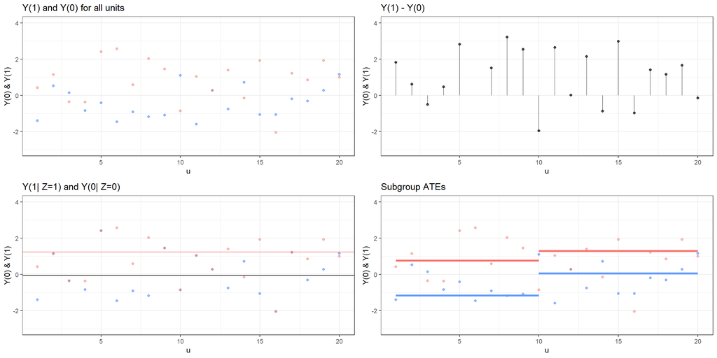

### 3.1.25 Potential outcomes: heterogeneous effects

The average of the differences $\approx$ difference of averages

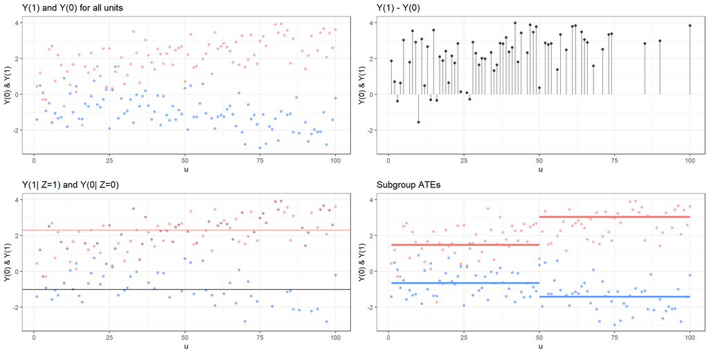

### 3.1.26 Potential outcomes: heterogeneous effects

**Question**: $\approx$ or $=$?

### 3.1.27 Exercise your potential outcomes 1

Consider the following potential outcomes table:

| Unit | Y(0) | Y(1) | $\tau_i$ |
| --- | --- | --- | --- |
| 1 | 4 | 3 |  |
| 2 | 2 | 3 |  |
| 3 | 1 | 3 |  |
| 4 | 1 | 3 |  |
| 5 | 2 | 3 |  |

**Questions for us:** What are the unit level treatment effects? What is the average treatment effect?

### 3.1.28 Exercise your potential outcomes 2

Consider the following potential outcomes table:

| In treatment? | Y(0) | Y(1) |
| --- | --- | --- |
| Yes |  | 2 |
| No | 3 |  |
| No | 1 |  |
| Yes |  | 3 |
| Yes |  | 3 |
| No | 2 |  |

**Questions for us:** Fill in the blanks.

- Assuming a constant treatment effect of $+1$
- Assuming a constant treatment effect of $-1$
- Assuming an *average* treatment effect of $0$

What is the actual treatment effect?

## 3.2 Pause

Take a short break!

[figure not shown]

## 3.3 Endogeneous subgroups

### 3.3.1 Endogeneous Subgroups

Experiments often give rise to endogenous subgroups. The potential outcomes framework can make it clear why this can cause problems.

### 3.3.2 Heterogeneous Effects with Endogeneous Categories

- Problems arise in analyses of subgroups when the categories themselves are affected by treatment
- Example from our work:
  - You want to know if an intervention affects reporting on violence against women
  - You measure the share of all subjects that experienced violence that file reports
  - The problem is that which subjects experienced violence is itself a function of treatment

### 3.3.3 Heterogeneous Effects with Endogeneous Categories

- **Violence(Treatment)**
- **Reporting(Treatment, Violence)**

|  | V(0) | V(1) | R(0,1) | R(1,1) | R(0,0) | R(1,0) |
| --- | --- | --- | --- | --- | --- | --- |
| Type 1 (reporter) | 1 | 1 | 1 | 1 | 0 | 0 |
| Type 2 (non reporter) | 1 | 0 | 0 | 0 | 0 | 0 |

Expected reporting given violence in control = Pr(Type 1)

Expected reporting given violence in treatment = 100%

**Question**: What is the actual effect of treatment on the propensity to report violence?

### 3.3.4 Heterogeneous Effects with Endogeneous Categories

It is possible that in truth no one’s reporting behavior has changed, what has changed is the propensity of people with different propensities to report to experience violence:

|  | Reporter | *No Violence* | *Violence* | % Report |
| --- | --- | --- | --- | --- |
| Control | Yes No | 25 25 | 25 25 | $\frac{25}{25+25}=50\%$ |
| Treatment | Yes No | 25 50 | 25 0 | $\frac{25}{25+0}=100\%$ |

### 3.3.5 Heterogeneous Effects with Endogeneous Categories

This problem can arise as easily in seemingly simple field experiments. Example:

- In one study we provided constituents with information about performance of politicians
- We told politicians in advance so that they could take action
- We wanted to see whether voters punished poorly performing politicians

What’s the problem?

### 3.3.6 Endogeneous Categories: Test yourself

Question for us:

- Quotas for women are randomly placed in a set of constituencies in year 1. All winners in these areas are women; in other areas only some are.
- In year 2 these quotas are then lifted.

Which problems face an endogenous subgroup issue?:

### 3.3.7 Endogeneous Categories: Test yourself

Which problems face an endogenous subgroup issue?:

### 3.3.8 Endogeneous Categories: Responses

In such cases you can:

- Examine the joint distribution of multiple outcomes
- Condition on pretreatment features only
- Engage in mediation analysis

### 3.3.9 Missing data can create an endogeneous subgroup problem

- It is well known that missing data can undo the magic of random assignment.
- One seemingly promising approach is to match into pairs *ex ante* and drop pairs together *ex post*.
- Say potential outcomes looked like this (2 pairs of 2 units):

| Pair | I | I | II | II |  |
| --- | --- | --- | --- | --- | --- |
| Unit | 1 | 2 | 3 | 4 | Average |
| Y(0) | 0 | 0 | 0 | 0 |  |
| Y(1) | -3 | 1 | 1 | 1 |  |
| $\tau$ | -3 | 1 | 1 | 1 | 0 |

### 3.3.10 Missing data

- Say though that treated cases are likely to drop out of the sample if things go badly (e.g. they get a negative score or die)
- Then you might see no attrition if those would-be attritors are not treated.
- You might assume you have no problem (after all, no attrition).
- No missing data when the normal cases happens to be selected

| Pair | I | I | II | II |  |
| --- | --- | --- | --- | --- | --- |
| Unit | 1 | 2 | 3 | 4 | Average |
| Y(0) | 0 |  | 0 |  | 0 |
| Y(1) |  | 1 |  | 1 | 1 |
| $\hat{\tau}$ |  |  |  |  | 1 |

### 3.3.11 Missing data

- But in cases in which you have attrition, dropping the pair doesn’t necessarily help.
- The problem is potential missingness still depends on potential outcomes
- The kicker is that the method can produce bias even if (*in fact*) there is no attrition!
- But missing data when the vulnerable cases happens to be selected

| Pair | I | I | II | II |  |
| --- | --- | --- | --- | --- | --- |
| Unit | 1 | 2 | 3 | 4 | Average |
| Y(0) |  | [0] | 0 |  | 0 |
| Y(1) | [-3] |  |  | 1 | 1 |
| $\hat{\tau}$ |  |  |  |  | 1 |

### 3.3.12 Missing data

Note: The right way to think about this is that bias **is a property of the strategy over possible realizations** of data and not normally a property of the estimator conditional on the data.

### 3.3.13 Multistage games

Multistage games can also present an endogenous group problem since collections of late stage players facing a given choice have been created by early stage players.

### 3.3.14 Multistage games

Question: Does **visibility** alter the extent to which subjects follow norms to punish antisocial behavior (and reward prosocial behavior)? Consider a **trust game** in which we are interested in how information on receivers affects their actions

Table 1: Return rates given investments under different conditions.

| Visibility Treatment | % invested (average) | Average % returned ...when 10% invested | Average % returned ...when 50% invested |
| --- | --- | --- | --- |
| Control: Masked information on respondents | 30% | 20% | 40% |
| Treatment: Full information on respondents | 30% | 0% | 60% |

What do we think? Does visibility make people react more to investments?

### 3.3.15 Multistage games

Imagine you could see all the potential outcomes, and they looked like this:

Table 2: Potential outcomes with (and without) identity protection.

| Offered behavior | Responder’s return decision (given type) Nice 1 | Responder’s return decision (given type) Nice 2 | Responder’s return decision (given type) Nice 3 | Responder’s return decision (given type) Mean 1 | Responder’s return decision (given type) Mean 2 | Responder’s return decision (given type) Mean 3 | Avg. |
| --- | --- | --- | --- | --- | --- | --- | --- |
| Invest 10% | 60% | 60% | 60% | 0% | 0% | 0% | 30% |
| Invest 50% | 60% | 60% | 60% | 0% | 0% | 0% | 30% |

**Conclusion**: Both the offer and the information condition are **completely irrelevant** for all subjects.

### 3.3.16 Multistage games

Unfortunately you only see a sample of the potential outcomes, and that looks like this:

Table 3: Outcomes when respondent is visible.

| Offered behavior | Responder’s return decision (given type) Nice 1 | Responder’s return decision (given type) Nice 2 | Responder’s return decision (given type) Nice 3 | Responder’s return decision (given type) Mean 1 | Responder’s return decision (given type) Mean 2 | Responder’s return decision (given type) Mean 3 | Avg. |
| --- | --- | --- | --- | --- | --- | --- | --- |
| Invest 10% |  |  |  | 0% | 0% | 0% | 0% |
| Invest 50% | 60% | 60% | 60% |  |  |  | 60% |

**False Conclusion**: When not protected, responders condition behavior *strongly* on offers (because offerers can select on type accurately)

**In fact**: The nice types invest more because they are nice. The responders return more to the nice types because they are nice.

### 3.3.17 Multistage games

Unfortunately you only see a (noisier!) sample of the potential outcomes, and that looks like this:

Table 4: Outcomes when respondent is not visible.

| Offered behavior | Responder’s return decision (given type) Nice 1 | Responder’s return decision (given type) Nice 2 | Responder’s return decision (given type) Nice 3 | Responder’s return decision (given type) Mean 1 | Responder’s return decision (given type) Mean 2 | Responder’s return decision (given type) Mean 3 | Avg. |
| --- | --- | --- | --- | --- | --- | --- | --- |
| Invest 10% |  |  | 60% |  | 0% | 0% | 20% |
| Invest 50% | 60% | 60% |  | 0% |  |  | 40% |

**False Conclusion**: When protected, responders condition behavior **less strongly** on offers (because offerers can select on type less accurately)

### 3.3.18 Multistage games

What to do?

**Solutions?**

1. Analysis *could* focus on the effect of treatment on respondent behavior, directly.
   - This would get the correct answer but to a different question (*Does information affect the share of contributions returned by subjects on average?*)
2. **Strategy method** can sometimes help address the problem, **but** note that that is (a) changing the question and (b) putting demands on respondent imagination and honesty
3. First mover action could be **directly manipulated**, but unless deception is used that is also changing the question
4. First movers could be **selected** because they act in predictable ways (bordering on deception?)

**Take away**: Proceed with extreme caution when estimating effects beyond the first stage.

## 3.4 Pause

Take a short break!

[figure not shown]

## 3.5 DAGs

*Directed Acyclic Graphs*

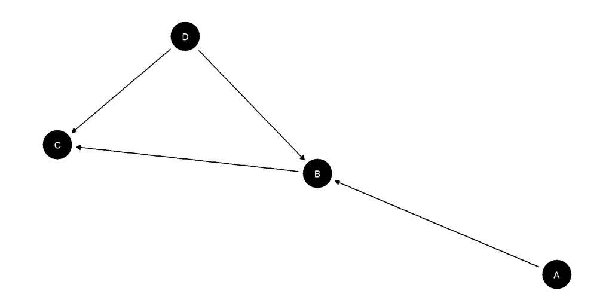

### 3.5.1 Key insight

The most powerful results from the study of DAGs give procedures for figuring out when conditioning aids or hinders causal identification.

- You can read off a **confounding** variable from a DAG.
  - You figure out what to condition on for causal identification.
- You can read off **“colliders”** from a DAG
  - Sometimes you have to *avoid* conditioning on these
- Sometimes a variable might be both, so
  - you have to condition on it
  - you have to avoid conditioning on it
  - Ouch.

### 3.5.2 Key resource

- Pearl’s book *Causality* is the key reference. Pearl (2009) (Though see also older work such as Pearl and Paz (1985))
- There is a lot of excellent material on Pearl’s page http://bayes.cs.ucla.edu/WHY/
- See also excellent material on Felix Elwert’s page http://www.ssc.wisc.edu/~felwert/causality/?page_id=66

### 3.5.3 Challenge for us

- Say you don’t like graphs. Fine.
- Consider this causal structure:
  - $Z = f_1(U_1, U_2)$
  - $X = f_2(U_2)$
  - $Y = f_3(X, U_1)$

Say $Z$ is temporally prior to $X$; it is correlated with $Y$ (because of $U_1$) and with $X$ (because of $U_2$).

**Question:** Would it be useful to “control” for $Z$ when trying to estimate the effect of $X$ on $Y$?

## 3.6 Challenge for us

- Say you don’t like graphs. Fine.
- Consider this causal structure:
  - $Z = f_1(U_1, U_2)$
  - $X = f_2(U_2)$
  - $Y = f_3(X, U_1)$

**Question:** Would it be useful to “control” for $Z$ when trying to estimate the effect of $X$ on $Y$?

**Answer:** Hopefully by the end of today you should see that the answer is obviously (or at least, plausibly) “no.”

## 3.7 Conditional independence and graph structure

- What DAGs do is tell you when one variable is independent of another variable given some third variable.
- Intuitively:
  - what variables “shield off” the influence of one variable on another
  - e.g. If inequality causes revolution *via* discontent, then inequality and revolution should be related to each other overall, but *not* related to each other *among those* that are content or *among those* that are discontent

### 3.7.1 Conditional independence

Variable sets $A$ and $B$ are conditionally independent, given $C$ if for all $a$, $b$, $c$:

$$\Pr(A = a | C = c) = \Pr(A = a | B = b, C = c)$$

Informally; given $C$, knowing $B$ tells you nothing more about $A$.

### 3.7.2 Conditional distributions: Factorization

- Consider a situation with variables $X_1, X_2, \dots X_n$
- The probability of outcome $x$ can always be written in the form $P(X_1 = x_1)P(X_2 = x_2|X_1=x_1)(X_3 = x_3|X_1=x_1, X_2 = x_2)\dots$.
- This can be done with any ordering of variables.
- However the representation can be greatly simplified if you can make use of a set of “parentage” relationships
- Given an ordering of variables, the **Markovian parents** of variable $X_j$ are the minimal set of variables such that when you condition on these, $X_j$ is independent of all other prior variables in the ordering
- We want to get to the point where we can can write: $P(x) = \prod_j(x_j | pa_j)$

### 3.7.3 Conditional distributions: Factorization from graphs

- We want to use causal graphs to represent these relations of conditional independence.
- Informally, an arrow, $A \rightarrow B$ means that $A$ is a cause of $B$: that is, under some conditions, a change in $A$ produces a change in $B$.
  - Arrows carry no information about the type of effect; e.g. sign, size, or whether different causes are complements or substitutes
- We say that arrows point from *parents* to *children*, and by extension from *ancestors* to *descendants*.
- These are parents *on the graph*; but we will connect them to Markovian parents in a probability distribution $P$.

### 3.7.4 Conditional distributions: Markov condition

- A DAG is just a graph in which some or all nodes are connected by *directed* edges (arrows) and there are no cyclical paths along these directed edges.
- Consider a DAG, $G$, and consider the ancestry relations implied by $G$: the distribution $P$ is *Markov relative to the graph* $G$ if every variable is independent of its nondescendants (in $G$) conditional on its parents (in $G$).
  - **Markov condition**: conditional on its parents, a variable is independent of its non-descendants.

Now we have what we need to simplify: **if the Markov condition is satisfied**, then instead of writing the full probability as $P(x) = P(x_1)P(x_2|x_1)P(x_3|x_1, x_2)$ we can write $P(x) = \prod_i P(x_i |pa_i)$.

### 3.7.5 Illustration

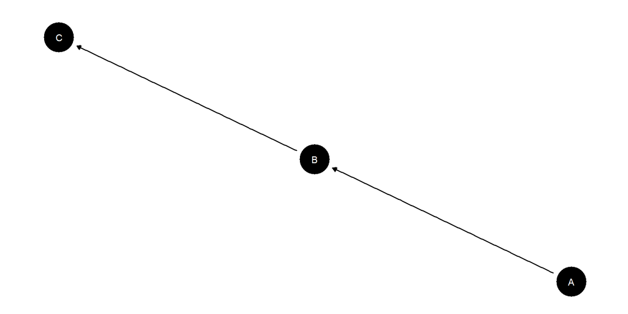

If $P(a,b,c)$ is Markov relative to this graph then: $C$ is independent of $A$ given $B$

And instead of

$$\Pr(a,b,c) = \Pr(a)\Pr(a|b)\Pr(c|a, b)$$

we could now write:

$$\Pr(a,b,c) = \Pr(a)\Pr(a|b)\Pr(c|b)$$

### 3.7.6 Conditional distributions and interventions

We want the graphs to be able to represent the effects of interventions.

Pearl uses `do` notation to capture this idea.

$$\Pr(X_1, X_2,\dots | do(X_j = x_j))$$
or

$$\Pr(X_1, X_2,\dots | \hat{x}_j)$$

denotes the distribution of $X$ when a particular node (or set of nodes) is *intervened upon* and forced to a particular level, $x_j$.

### 3.7.7 Conditional distributions given `do` operations

Note, in general:
$$\Pr(X_1, X_2,\dots | do(X_j = x_j')) \neq \Pr(X_1, X_2,\dots | X_j = x_j')$$
as an example we might imagine a situation where:

- for men, binary $X$ always causes $Y=1$
- for women, $Y=0$ regardless of $X$
- $X=1$ for men only.

In that case $\Pr(Y=1 | X = 1) = 1$ but $\Pr(Y=1 | do(X = 1)) = .5$

### 3.7.8 Conditional distributions given `do` operations

A DAG is “*causal Bayesian network*” or “*Causal DAG*” if (and only if) the probability distribution resulting from setting some set $X_i$ to $\hat{x'}_i$ (i.e. `do(X=x')`) is:

$$P_{\hat{x}_i}: P(x_1,x_2,\dots x_n|\hat{x}_i) = \mathbb{I}(x_i = x_i')\prod_{-i}P(x_j|pa_j)$$

This means that there is only probability mass on vectors in which $x_i = x_i'$ (reflecting the success of control) and all other variables are determined by their parents, given the values that have been set for $x_i$.

### 3.7.9 Conditional distributions given `do` operations

Illustration, say we have binary $X$ causes binary $M$ which cases binary $Y$; say we intervene and set $M=1$. Then what is the distribution of $(x,m,y)$?

It is:

$$\Pr(x,m,y) = \Pr(x)\mathbb I(M = 1)\Pr(y|m)$$

## 3.8 Graphical reading of Conditional Independence

### 3.8.1 Conditional Independence and $d$-separation

- We now have a well defined sense in which the arrows on a graph represent a causal structure and capture the conditional independence relations implied by the causal structure.
- Of course any graph might represent many different probability distributions $P$
- We can now start reading off from a graph when there is or is not conditional independence between sets of variables

### 3.8.2 Conditional independence on paths graphs

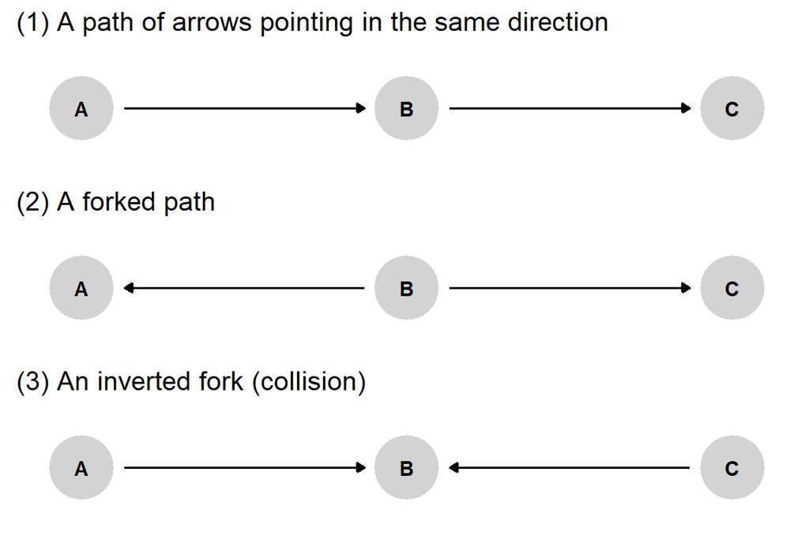

Three elemental relations of conditional independence.

### 3.8.3 Conditional independence from graphs

$A$ and $B$ are *conditionally independent*, given $C$ if on *every* path between $A$ and $B$:

- there is some chain ($\bullet\rightarrow \bullet\rightarrow\bullet$ or $\bullet\leftarrow \bullet\leftarrow\bullet$) or fork ($\bullet\leftarrow \bullet\rightarrow\bullet$) with the central element in $C$,

or

- there is an inverted fork ($\bullet\rightarrow \bullet\leftarrow\bullet$) with the central element (and its descendants) *not* in $C$

Notes:

- In this case we say that $A$ and $B$ are d-separated by $C$.
- $A$, $B$, and $C$ can all be sets
- Note that a path can involve arrows pointing any direction $\bullet\rightarrow \bullet\rightarrow \bullet\leftarrow \bullet\rightarrow\bullet$

### 3.8.4 Test yourself

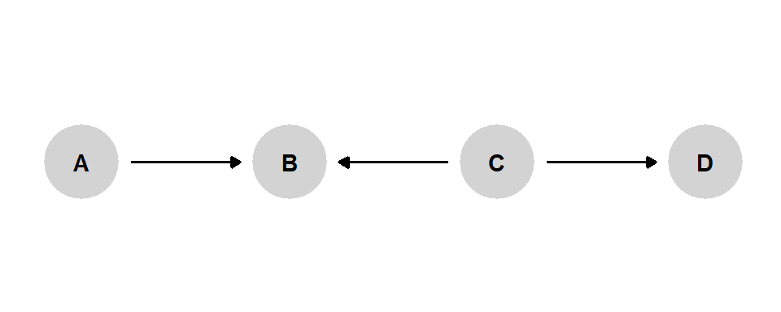

Are A and D unconditionally independent:

- if you do not condition on anything?
- if you condition on B?
- if you condition on C?
- if you condition on B and C?

### 3.8.5 Back to this example

- $Z = f_1(U_1, U_2)$
- $X = f_2(U_2)$
- $Y = f_3(X, U_1)$
1. Let’s graph this
2. Now: say we removed the arrow from $X$ to $Y$
   - Would you expect to see a correlation between $X$ and $Y$ if you did not control for $Z$
   - Would you expect to see a correlation between $X$ and $Y$ if you did control for $Z$

### 3.8.6 Back to this example

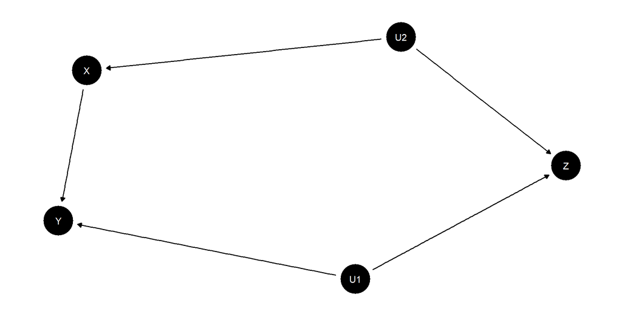

Now: say we removed the arrow from $X$ to $Y$ - Would you expect to see a correlation between $X$ and $Y$ if you did not control for $Z$ - Would you expect to see a correlation between $X$ and $Y$ if you did control for $Z$

## 3.9 Causal models

### 3.9.1 From graphs to Causal Models

A “**causal model**” is:

1.Variables

- An ordered list of $n$ endogenous nodes, $\mathcal{V}= (V^1, V^2,\dots, V^n)$, with a specification of a range for each of them
- A list of $n$ exogenous nodes, $\Theta = (\theta^1, \theta^2,\dots , \theta^n)$
2. A list of $n$ functions $\mathcal{F}= (f^1, f^2,\dots, f^n)$, one for each element of $\mathcal{V}$ such that each $f^i$ takes as arguments $\theta^i$ as well as elements of $\mathcal{V}$ that are *prior* to $V^i$ in the ordering
3. A probability distribution over $\Theta$

### 3.9.2 From graphs to Causal Models

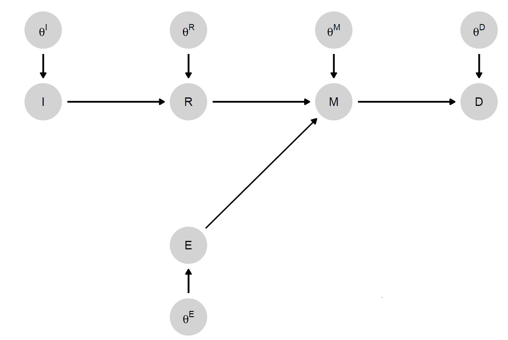

A simple causal model in which high inequality ($I$) affects democratization ($D$) via redistributive demands ($R$) and mass mobilization ($M$), which is also a function of ethnic homogeneity ($E$). Arrows show relations of causal dependence between variables.

### 3.9.3 Effects on a DAG

- Learning about effects *given* a model means learning about $F$ and *also* the distribution of shocks ($\Theta$).
- For discrete data this can be reduced to a question about learning about the distribution of $\Theta$ only.

### 3.9.4 Effects on a DAG

For instance the simplest model consistent with $X \rightarrow Y$:

- Endogenous Nodes = $\{X, Y\}$, both with range $\{0,1\}$
- Exogenous Nodes = $\{\theta^X, \theta^Y\}$, with ranges $\{\theta^X_0, \theta^X_1\}$ and $\{\theta^Y_{00}\theta^Y_{01}, \theta^Y_{10}, \theta^Y_{11}\}$
- Functional equations:
  - $f_Y$: $\theta^Y =\theta^Y_{ij} \rightarrow \{Y = i \text{ if } X=0; Y = j \text{ if } X=1\}$
  - $f_X$: $\theta^X =\theta^X_{i} \rightarrow \{X = i\}$
- Distributions on $\Theta$: $\Pr(\theta^i = \theta^i_k) = \lambda^i_k$

### 3.9.5 Effects as statement about exogeneous variables

What is the probability that $X$ has a positive causal effect on $Y$?

- This is equivalent to: $\Pr(\theta^Y =\theta^Y_{01}) = \lambda^Y_{01}$
- So we want to learn about the distributions of the exogenous nodes

### 3.9.6 Recap:

- DAGs
- Causality

### 3.9.7 Recap: Key features of graphs

- Directed
- Acyclic
- The missing arcs are the really important ones
- Implicitly there are shocks going into every node
- These graphs represent Nonparametric structural equation models NPSEMs
- But you cannot read off the size or direction of effects from a DAG

### 3.9.8 Recap: Things you need to know about causal inference

1. A causal claim is a statement about what didn’t happen.
2. There is a fundamental problem of causal inference.
3. You can estimate average causal effects even if you cannot observe any individual causal effects.
4. If you know that $A$ causes $B$ and that $B$ causes $C$, this does not mean that you know that $A$ causes $C$.
5. $X$ can cause $Y$ even if there is no “causal path” connecting $X$ and $Y$.
6. $X$ can cause $Y$ even if $X$ is not a necessary condition or a sufficient condition for $Y$.
7. Estimating average causal effects does not require that treatment and control groups are identical.
8. There is no causation without manipulation.

http://egap.org/resources/guides/causality/

# 4 Inquiries

*Well posed questions*

## 4.1 Outline

- Types of estimands
- Principal strata
- Identification
- Backdoor
- Frontdoor
- `dagitty`

## 4.2 Estimands and inquiries

- Your **inquiry** is your question and the **estimand** is the true (generally unknown) answer to the inquiry
- The estimand is the thing you want to estimate
- If you are estimating something you should be able to say what your estimand is
- You are responsible for your estimand. Your estimator will not tell you what your estimand is
- Just because you can calculate something does not mean that you have an estimand
- You can test a hypothesis without having an estimand

Read: [II ch 4](https://macartan.github.io/integrated_inferences/HJC4.html), [DD, ch 7](https://book.declaredesign.org/declaration-diagnosis-redesign/defining-inquiry.html)

### 4.2.1 Estimands: ATE, ATT, ATC, S-, P-

- ATE is Average Treatment Effect (all units)
- ATT is Average Treatment Effect on the Treated
- ATC is Average Treatment Effect on the Controls

### 4.2.2 Estimands: ATE, ATT, ATC, S-, P-

Say that units are randomly assigned to treatment in different strata (maybe just one); with fixed, though possibly different, shares assigned in each stratum. Then the key estimands and estimators are:

| Estimand | Estimator |
| --- | --- |
| $\tau_{ATE} \equiv \mathbb{E}[\tau_i]$ | $\widehat{\tau}_{ATE} = \sum\nolimits_{x} \frac{w_x}{\sum\nolimits_{j}w_{j}}\widehat{\tau}_x$ |
| $\tau_{ATT} \equiv \mathbb{E}[\tau_i \| Z_i = 1]$ | $\widehat{\tau}_{ATT} = \sum\nolimits_{x} \frac{p_xw_x}{\sum\nolimits_{j}p_jw_j}\widehat{\tau}_x$ |
| $\tau_{ATC} \equiv \mathbb{E}[\tau_i \| Z_i = 0]$ | $\widehat{\tau}_{ATC} = \sum\nolimits_{x} \frac{(1-p_x)w_x}{\sum\nolimits_{j}(1-p_j)w_j}\widehat{\tau}_x$ |

where $x$ indexes strata, $p_x$ is the share of units in each stratum that is treated, and $w_x$ is the size of a stratum.

### 4.2.3 Estimands: ATE, ATT, ATC, S-, P-, C-

In addition, each of these can be targets of interest:

- for the **population**, in which case we refer to PATE, PATT, PATC and $\widehat{PATE}, \widehat{PATT}, \widehat{PATC}$
- for a **sample**, in which case we refer to SATE, SATT, SATC, and $\widehat{SATE}, \widehat{SATT}, \widehat{SATC}$

And for different subgroups,

- given some value on a covariate, in which case we refer to CATE (conditional average treatment effect)

### 4.2.4 Broader classes of estimands: LATE/CATE

The CATEs are **conditional** average treatment effects, for example the effect for men or for women. These are straightfoward.

However we might also imagine conditioning on unobservable or counterfactual features.

- The LATE (or CACE: “complier average causal effect”) asks about the effect of a treatment ($X$) on an outcome ($Y$) *for people that are responsive to an encouragement* ($Z$)

$$LATE = \frac{1}{|C|}\sum_{j\in C}(Y_j(X=1) - Y_j(X=0))$$
$$C:=\{j:X_j(Z=1) > X_j(Z=0) \}$$

We will return to these in the study of instrumental variables.

### 4.2.5 Quantile estimands

Other ways to condition on potential outcomes:

- A *quantile* treatment effect: You might be interested in the difference between the median $Y(1)$ and the median $Y(0)$ (Imbens and Rubin (2015) 20.3.1)
- or even be interested in the median $Y(1) - Y(0)$. Similarly for other quantiles.

### 4.2.6 Model estimands

Many inquiries are averages of individual effects, even if the groups are not known, but they do not have to be:

- The RDD estimand is a statement about what effects *would be* at a threshold; it can be defined under a model even if no actual individuals are at the threshold. We imagine average potential outcomes as a function of treatment $Z$ and running variable $X$, $f(z, x)$ and define:
  $$\tau_{RDD} := f(1, x^*) - f(0, x^*)$$

### 4.2.7 Distribution estimands

Many inquiries are averages of individual effects, even if the groups are not known,

But they do not have to be:

- Inquiries might relate to distributional quantities such as:
  - The effect of treatment on the variance in outcomes: $var(Y(1)) - var(Y(0))$
  - The variance of treatment effects: $var(Y(1) - Y(0))$
  - Other inequality measures (e.g. Ginis; (Imbens and Rubin (2015) 20.3.2))

You might even be interested in $\min(Y_i(1) - Y_i(0))$.

### 4.2.8 Spillover estimands

There are lots of interesting “spillover” estimands.

Imagine there are three individuals and each person’s outcomes depends on the assignments of all others. For instance $Y_1(Z_1, Z_2, Z_3$, or more generally, $Y_i(Z_i, Z_{i+1 (\text{mod }3)}, Z_{i+2 (\text{mod }3)})$.

Then three estimands might be:

- $\frac13\left(\sum_{i}{Y_i(1,0,0) - Y_i(0,0,0)}\right)$
- $\frac13\left(\sum_{i}{Y_i(1,1,1) - Y_i(0,0,0)}\right)$
- $\frac13\left(\sum_{i}{Y_i(0,1,1) - Y_i(0,0,0)}\right)$

Interpret these. What others might be of interest?

### 4.2.9 Differences in CATEs and interaction estimands

A difference in CATEs is a well defined estimand that might involve interventions on one node only:

- $\mathbb{E}_{\{W=1\}}[Y(X=1) - Y(X=0)] - \mathbb{E}_{\{W=0\}}[Y(X=1) - Y(X=0)]$

It captures differences in effects.

An *interaction* is an effect on an effect:

- $\mathbb{E}[Y(X=1, W=1) - Y(X=0, W=1)] - \mathbb{E}[Y(X=1, W=0) - Y(X=0, W=0)]$

Note in the latter the expectation is taken over the whole population.

### 4.2.10 Mediation estimands and complex counterfactuals

Say $X$ can affect $Y$ directly, or indirectly through $M$. then we can write potential outcomes as:

- $Y(X=x, M=m)$
- $M(X=x)$

We can then imagine inquiries of the form:

- $Y(X=1, M=M(X=1)) - Y(X=0, M=M(X=0))$
- $Y(X=1, M=1) - Y(X=0, M=1)$
- $Y(X=1, M=M(X=1)) - Y(X=1, M=M(X=0))$

Interpret these. What others might be of interest?

### 4.2.11 Mediation estimands and complex counterfactuals

Again we might imagine that these are defined with respect to some group:

- $A = \{i|Y_i(1, M(X=1)) > Y_i(0, M(X=0))\}$
- $\frac{1}{|A|} \sum_{i\in A}(Y(1, 1) > Y(0, 1))$

here, *among those for whom* $X$ has a positive effect on $Y$, for what share would there be a positive effect if $M$ were fixed at 1?

### 4.2.12 Causes of effects and effects of causes

In qualitative research a particularly common inquiry is “did $X=1$ cause $Y=1$?

This is often given as a probability, the “probability of causation” (though at the case level we might better think of this probability as an estimate rather than an estimand):

$$\Pr(Y_i(0) = 0 | Y_i(1) = 1, X = 1)$$

### 4.2.13 Causes of effects and effects of causes

Intuition: What’s the probability $X=1$ caused $Y=1$ in an $X=1, Y=1$ case drawn from a large population with the following experimental distribution:

|  | Y=0 | Y=1 | All |
| --- | --- | --- | --- |
| X=0 | 1 | 0 | 1 |
| X=1 | 0.25 | 0.75 | 1 |

### 4.2.14 Causes of effects and effects of causes

Intuition: What’s the probability $X=1$ caused $Y=1$ in an $X=1, Y=1$ case drawn from a large population with the following experimental distribution:

|  | Y=0 | Y=1 | All |
| --- | --- | --- | --- |
| X=0 | 0.75 | 0.25 | 1 |
| X=1 | 0.25 | 0.75 | 1 |

### 4.2.15 Actual causation

Other inquiries focus on distinguishing between causes.

For the Billy Suzy problem (Hall 2004), Halpern (2016) focuses on “actual causation” as a way to distinguish between Suzy and Billy:

> Imagine Suzy and Billy, simultaneously throwing stones at a bottle. Both are excellent shots and hit whatever they aim at. Suzy’s stone hits first, knocks over the bottle, and the bottle breaks. However, Billy’s stone *would* have hit had Suzy’s not hit, and again the bottle would have broken. Did Suzy’s throw cause the bottle to break? Did Billy’s?

### 4.2.16 Actual causation

Actual Causation:

1. $X=x$ and $Y=y$ both happened;
2. there is some set of variables, $\mathcal W$, such that if they were fixed at the levels that they *actually took* on in the case, and if $X$ were to be changed, then $Y$ would change (where $\mathcal W$ can also be an empty set);
3. no strict subset of $X$ satisfies 1 and 2 (there is no redundant part of the condition, $X=x$).

### 4.2.17 Actual causation

- Suzy: Condition 2 is met if Suzy’s throw made a difference, counterfactually speaking—with the important caveat that, in determining this, we are permitted to condition on Billy’ stone not hitting the bottle.
- Billy: Condition 2 is not met.

An inquiry: for what share in a population is a possible cause an actual cause?

### 4.2.18 Pearl’s ladder

Pearl (e.g. Pearl and Mackenzie (2018)) describes three types of inquiry:

| Level | Activity | Inquiry |
| --- | --- | --- |
| Association | “Seeing” | If I see $X=1$ should I expect $Y=1$? |
| Intervention | “Doing” | If I set $X$ to $1$ should I expect $Y=1$? |
| Counterfactual | “Imagining” | If $X$ were $0$ instead of 1, would $Y$ then be $0$ instead of $1$? |

### 4.2.19 Pearl’s ladder

We can understand these as asking different types of questions about a causal model

| Level | Activity | Inquiry |
| --- | --- | --- |
| Association | “Seeing” | $\Pr(Y=1\|X=1)$ |
| Intervention | “Doing” | $\mathbb{E}[\mathbb{I}(Y(1)=1)]$ |
| Counterfactual | “Imagining” | $\Pr(Y(1)=1 \& Y(0)=0)$ |

The third is qualitatively different because it requires information about two mutually incompatible conditions for units. This is not (generally ) recoverable directly from knowledge of $\Pr(Y(1)=1)$ and $\Pr(Y(0)=0)$.

## 4.3 Inquiries as statements about principal strata

Given a causal model over nodes with discrete ranges, inquiries can generally be described as summaries of the distributions of exogenous nodes.

We already saw two instances of this:

- The probability that $X$ has a positive effect on $Y$ in an $X \rightarrow Y$ model is $\lambda^Y_{01}$ (last lecture)
- The share of “compliers” in an IV model $Z \rightarrow X \rightarrow Y \leftrightarrow X$ is $\lambda^X_{01}$

## 4.4 Identification

*What it is. When you have it. What it’s worth.*

### 4.4.1 Identification

Informally a quantity is “identified” if it can be “recovered” once you have enough data.

Say for example average wage is $x$ in some very large population. If I gather lots and lots of data on the wages of individuals and take the average then then my estimate will ultimately let be figure out $x$.

- If $x$ is $1 then my estimate will end up centered on $1.
- If it is $2 it will end up centered on $2.

### 4.4.2 Identification (Definition)

- **Identifiability** Let $Q(M)$ be a query defined over a class of models $\mathcal M$, then $Q$ is identifiable if $P(M_1) = P(M_2) \rightarrow Q(M_1) = Q(M_1)$.
- **Identifiability with constrained data** Let $Q(M)$ be a query defined over a class of models $\mathcal M$, then $Q$ is identifiable from features $F(M)$ if $F(M_1) = F(M_2) \rightarrow Q(M_1) = Q(M_1)$.

Based on Defn 3.2.3 in Pearl.

- **Essentially**: Each underlying value produces a unique data distribution. When you see that distribution you recover the parameter.

### 4.4.3 Identification (Example without identification)

Informally a quantity is “identified” if it can be “recovered” once you have enough data.

- Say for example average wage is $x^m$ for men and $x^w$ for women (in some very large population).
- If I gather lots and lots of data on the wages of (male and female) couples, e.g. $x^c_i = x^m_i + x^w_i$ then, although this will be informative, it will never be sufficient to recover $x^m$ for men and $x^w$.
- I can recover $x^c$, but there are too many combinations of possible values of $x^m$ and $x^w$ consistent with the observed data.

### 4.4.4 Identification : Goal

Our goal in causal inference is to estimate quantities such as:

$$\Pr(Y|\hat{x})$$

where $\hat{x}$ is interpreted as $X$ set to $x$ by “external” control. Equivalently: $do(X=x)$ or sometimes $X \leftarrow x$.

- If this quantity is **identifiable** then we can recover it with infinite data.
- If it is not identifiable, then, even in the best case, we are not guaranteed to get the right answer.

*Are there general rules for determining whether this quantity can be identified?* Yes.

### 4.4.5 Identification : Goal

Note first, identifying

$$\Pr(Y|x)$$

is easy.

But we are not always interested in identifying the distribution of $Y$ given *observed* values of $x$, but rather, the distribution of $Y$ if $X$ is *set* to $x$.

## 4.5 Levels and effects

If we can identify the controlled distribution we can calculate other causal quantities of interest.

For example for a binary $X, Y$ the causal effect of $X$ on the probability that $Y=1$ is:

$$\Pr(Y=1|\hat{x}=1) - \Pr(Y=1|\hat{x}=0)$$

Again, **this is not the same as**:

$$\Pr(Y=1|x=1) - \Pr(Y=1|x=0)$$

It’s the difference between seeing and doing.

### 4.5.1 When to condition? What to condition on?

The key idea is that you want to find a set of variables such that when you condition on these you get what you would get if you used a `do` operation.

Intuition:

- You could imagine creating a “mutilated” graph by removing all the arrows leading *out* of *X*
- Then select a set of variables, $Z$, such that $X$ and $Y$ are d-separated by $Z$ on the the mutilated graph
- When you condition on these you are making sure that any covariation between $X$ and $Y$ is covariation that is due to the effects of $X$

### 4.5.2 Illustration

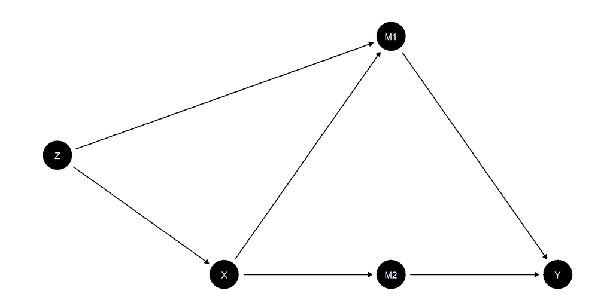

### 4.5.3 Illustration: Remove paths out

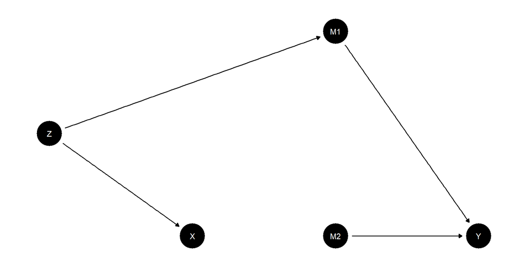

### 4.5.4 Illustration: Block backdoor path

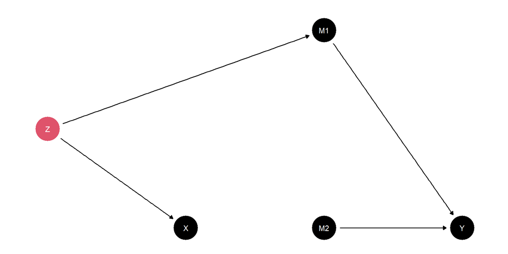

### 4.5.5 Illustration: Why not like this?

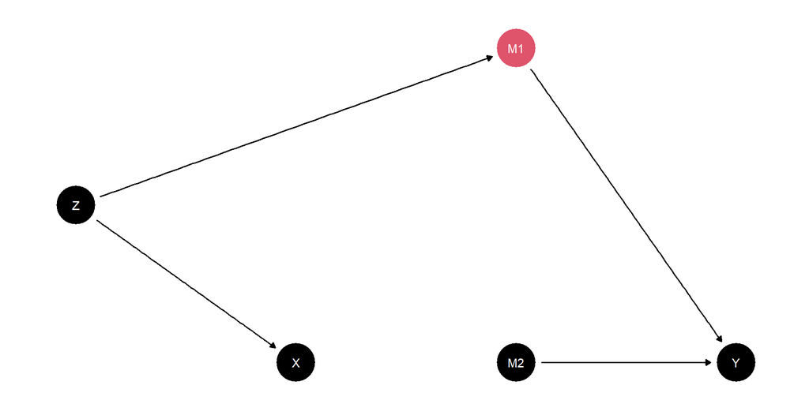

### 4.5.6 Identification

- Three results (“Graphical Identification Criteria”)
  - Backdoor criterion
  - Adjustment criterion
  - Frontdoor criterion
- There are more

### 4.5.7 Backdoor Criterion: (Pearl 1995)

The **backdoor criterion** is satisfied by $Z$ (relative to $X$, $Y$) if:

1. No node in $Z$ is a descendant of $X$
2. $Z$ blocks every **backdoor** path from $X$ to $Y$ (i.e. every path that contains an arrow into $X$)

In that case you can identify the effect of $X$ on $Y$ by conditioning on $Z$:

$$P(Y=y | \hat{x}) = \sum_z P(Y=y| X = x, Z=z)P(z)$$
(This is eqn 3.19 in Pearl (2000))

### 4.5.8 Backdoor Criterion: (Pearl 1995)

$$P(Y=y | \hat{x}) = \sum_z P(Y=y| X = x, Z=z)P(z)$$

- No notion of a linear control or anything like that; idea really is like blocking: think lots of discrete data and no missing patterns
- Note this is a formula for a (possibly counterfactual) *level*; a counterfactual difference would be given in the obvious way by:

$$P(Y=y | \hat{x}) - P(Y=y | \hat{x}')$$

### 4.5.9 Backdoor Proof

Following Pearl (2009), Chapter 11. Let $T$ denote the set of parents of $X$: $T := pa(X)$, with (possibly vector valued) realizations $t$. These might not all be observed.

If the backdoor criterion is satisfied, we have:

1. $Y$ is independent of $T$, given $X$ and observed data, $Z$ (since $Z$ blocks backdoor paths)
2. $X$ is independent of $Z$ given $T$. (Since $Z$ includes only nondescendents)
- The intervention level relates to the observational level as follows:
  $$p(y|\hat{x}) = \sum_{t\in T} p(t)p(y|x, t)$$
- Think of this as *fully accounting for the (possibly unobserved) causes of $X$, $T$*

### 4.5.10 Backdoor Proof

- But of course we do not observe $T$, rather we observe $Z$. So we now need to write everything in terms of $Z$ rather than $T$.

We bring $Z$ into the picture by writing:
$$p(y|\hat{x}) = \sum_{t\in T} p(t) \sum_z p(y|x, t, z)p(z|x, t)$$

- Then using the two conditions above:
  1. replace $p(y|x, t, z)$ with $p(y | x, z)$
  2. replace $p(z|x, t)$ with $p(z|t)$

This gives:
$$p(y|\hat x) = \sum_{t \in T} p(t) \sum_z p(y|x, z)p(z|t)$$

### 4.5.11 Backdoor Proof

So, cleaning up, we can get rid of $T$:

$$p(y|\hat{x}) = \sum_z p(y|x, z)\sum_{t\in T} p(z|t)p(t) = \sum_z p(y| x, z)p(z)$$

### 4.5.12 Backdoor proof figure

For intuition:

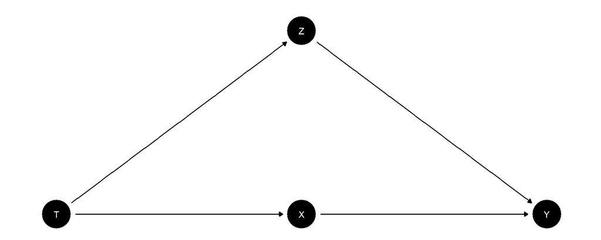

We would be happy if we could condition on the parent $T$, but $T$ is not observed. However we can use $Z$ instead making use of the fact that:

1. $p(y|x, t, z) = p(y | x, z)$ (since $Z$ blocks)
2. $p(z|x, t) = p(z|t)$ (since $Z$ is upstream and blocked by parents, $T$)

### 4.5.13 Adjustment criterion

See Shpitser, VanderWeele, and Robins (2012)

The adjustment criterion is satisfied by $Z$ (relative to $X$, $Y$) if:

1. no element of $Z$ is a descendant in the mutilated graph of any variable $W\not\in X$ which lies on a proper causal path from $X$ to $Y$
2. $Z$ blocks all **noncausal paths** from $X$ to $Y$

Note:

- mutilated graph: remove arrows pointing into $X$
- proper pathway: A *proper* causal pathway from $X$ to $Y$ only intersects $X$ at the endpoint

### 4.5.14 These are different. Simple illustration.

Here $Z$ satisfies the adjustment criterion but not the backdoor criterion:

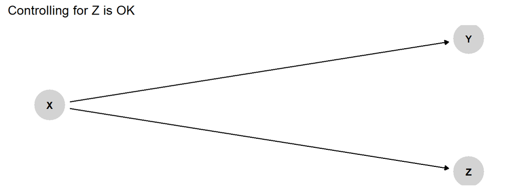

$Z$ is descendant of $X$ but it is not a descendant of a node on a path from $X$ to $Y$. No harm adjusting for $Z$ here, but not necessary either.

### 4.5.15 Frontdoor criterion (Pearl)

Consider this DAG:

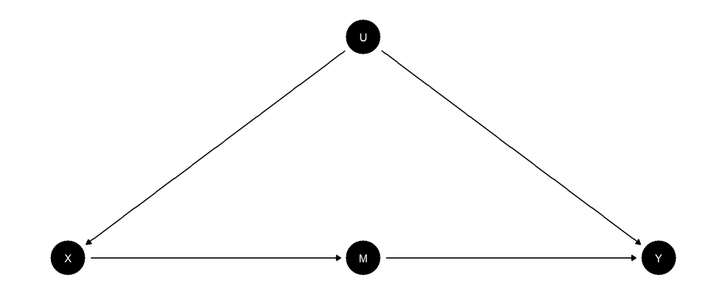

- The relationship between $X$ and $Y$ is confounded by $U$.
- However the $X\rightarrow Y$ effect is the product of the $X\rightarrow M$ effect and the $M\rightarrow Y$ effect

Why?

### 4.5.16 Identification through the front door

If:

- $M$ (possibly a set) blocks all *directed* paths from $X$ to $Y$
- there is no backdoor path $X$ to $M$
- $X$ blocks all backdoor paths from $M$ to $Y$ and
- all ($m,z$) combinations arise with positive probability

Then $\Pr(y| \hat x)$ is identifiable and given by:

$$\Pr(y| \hat x) = \sum_m\Pr(m|x)\sum_{x'}\left(\Pr(y|m,x')\Pr(x')\right)$$

### 4.5.17 Frontdoor criterion (Proof)

We want to get $\Pr(y | \hat x)$

From the graph the joint distribution of variables is:

$$\Pr(x,m,y,u) = \Pr(u)\Pr(x|u)\Pr(m|x)\Pr(y|m,u)$$
If we intervened on $X$ we would have ($\Pr(X = x |u)=1$):

$$\Pr(m,y,u | \hat x) = \Pr(u)\Pr(m|x)\Pr(y|m,u)$$
If we sum up over $u$ and $m$ we get:

$$\Pr(m,y| \hat x) = \Pr(m|x)\sum_u\left(\Pr(y|m,u)\Pr(u)\right)$$
$$\Pr(y| \hat x) = \sum_m\Pr(m|x)\sum_u\left(\Pr(y|m,u)\Pr(u)\right)$$

The first part is fine; the second part however involves $u$ which is unobserved. So we need to get the $u$ out of $\sum_u\left(\Pr(y|m,u)\Pr(u)\right)$.

### 4.5.18 Frontdoor criterion

Now, from the graph:

1. $M$ is d-separated from $U$ by $X$:

$$\Pr(u|m, x) = \Pr(u|x)$$
2. $X$ is d-separated from $Y$ by $M$, $U$

$$\Pr(y|x, m, u) = \Pr(y|m,u)$$
That’s enough to get $u$ out of $\sum_u\left(\Pr(y|m,u)\Pr(u)\right)$

### 4.5.19 Frontdoor criterion

$$\sum_u\left(\Pr(y|m,u)\Pr(u)\right) = \sum_x\sum_u\left(\Pr(y|m,u)\Pr(u|x)\Pr(x)\right)$$

Using the 2 equalities we got from the graph:

$$\sum_u\left(\Pr(y|m,u)\Pr(u)\right) = \sum_x\sum_u\left(\Pr(y|x,m,u)\Pr(u|x,m)\Pr(x)\right)$$

So:

$$\sum_u\left(\Pr(y|m,u)\Pr(u)\right) = \sum_x\left(\Pr(y|m,x)\Pr(x)\right)$$

Intuitively: $X$ blocks the back door between $Z$ and $Y$ just as well as $U$ does

### 4.5.20 Frontdoor criterion

Substituting we are left with:

$$\Pr(y| \hat x) = \sum_m\Pr(m|x)\sum_{x'}\left(\Pr(y|m,x')\Pr(x')\right)$$

(The $'$ is to distinguish the $x$ in the summation from the value of $x$ of interest)

It’s interesting that $x$ remains in the right hand side in the calculation of the $m \rightarrow y$ effect, but this is because $x$ blocks a backdoor from $m$ to $y$

### 4.5.21 Front foor

Bringing all this together into a claim we have:

If:

- $M$ (possibly a set) blocks all *directed* paths from $X$ to $Y$
- there is no backdoor path $X$ to $M$
- $X$ blocks all backdoor paths from $M$ to $Y$ and
- all ($m,z$) combinations arise with positive probability

Then $\Pr(y| \hat x)$ is identifiable and given by:

$$\Pr(y| \hat x) = \sum_m\Pr(m|x)\sum_{x'}\left(\Pr(y|m,x')\Pr(x')\right)$$

### 4.5.22 Front foor

- This is a very elegant and surprising result
- There are not many obvious applications of it however
- The conditions would be violated for example if unobserved third things caused both $M$ and $Y$

## 4.6 In code: Dagitty

There is a package (Textor et al. 2016) for figuring out what to condition on.

```r
library(dagitty)
```

### 4.6.1 In code: Dagitty

Define a dag using dagitty syntax:

```r
g <- dagitty("dag{X -> M -> Y ; Z -> X ; Z -> R -> Y}")
```

There is then a simple command to check whether two sets are d-separated by a third set:

```r
dseparated(g, "X", "Y", "M")
```

```
[1] FALSE
```

```r
dseparated(g, "X", "Y", c("Z","M"))
```

```
[1] TRUE
```

### 4.6.2 Dagitty: Find adjustment sets

And a simple command to identify the adjustments needed to identify the effect of one variable on another:

```r
adjustmentSets(g, exposure = "X", outcome = "Y")
```

```
{ R }
{ Z }
```

### 4.6.3 Important Examples : Confounding

Example where $Z$ is correlated with $X$ and $Y$ and is a confounder

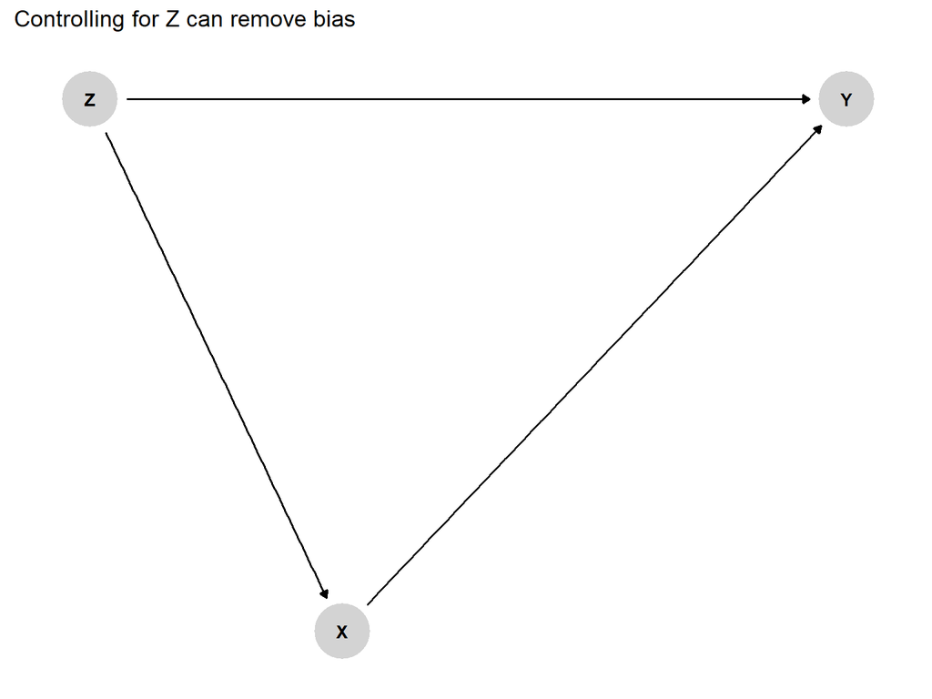

### 4.6.4 Confounding

Example where $Z$ is correlated with $X$ and $Y$ but it is *not* a confounder

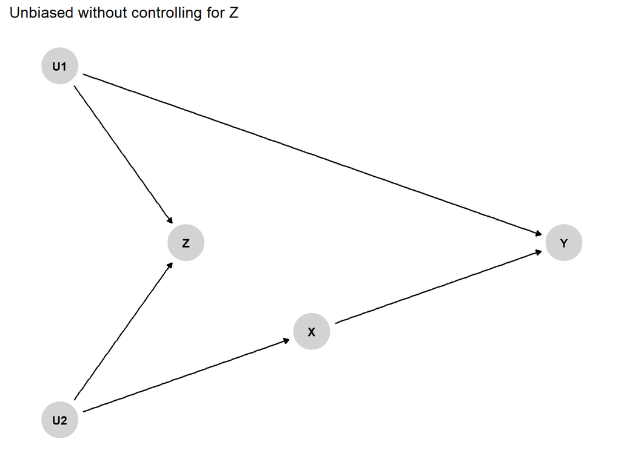

### 4.6.5 Important Examples : Collider

But controlling can also cause problems. In fact conditioning on a temporally pre-treatment variable could cause problems. Who’d have thunk? Here is an example from Pearl (2005):

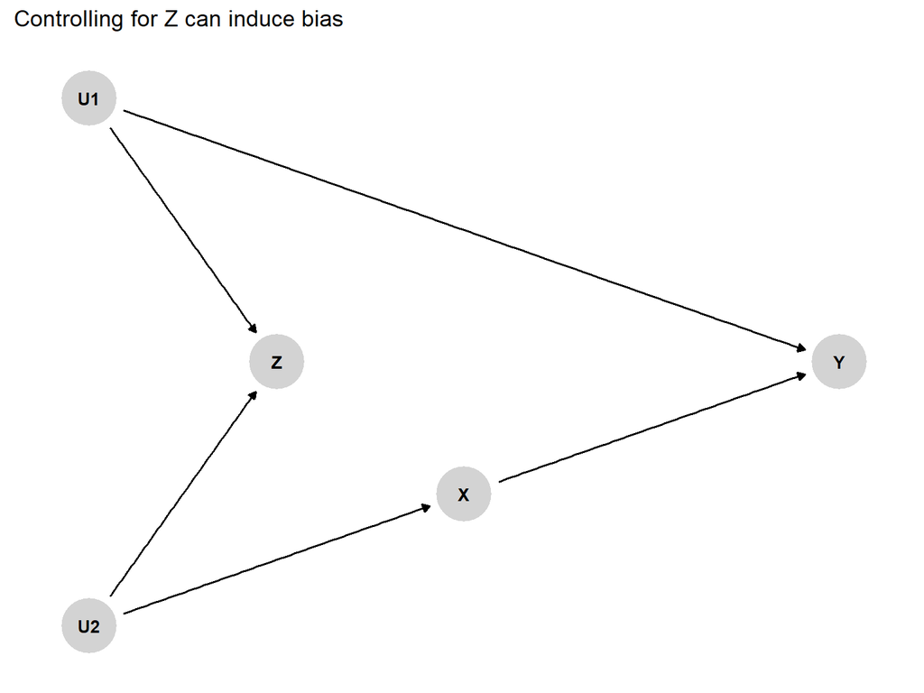

### 4.6.6 Illustration of identification failure from conditioning on a collider

```r
U1 <- rnorm(10000);  U2 <- rnorm(10000)
Z  <- U1+U2
X  <- U2 + rnorm(10000)/2
Y  <- U1*2 + X

lm_robust(Y ~ X) |> tidy() |> kable(digits = 2)
```

| term | estimate | std.error | statistic | p.value | conf.low | conf.high | df | outcome |
| --- | --- | --- | --- | --- | --- | --- | --- | --- |
| (Intercept) | -0.02 | 0.02 | -1.21 | 0.23 | -0.06 | 0.01 | 9998 | Y |
| X | 1.02 | 0.02 | 56.52 | 0.00 | 0.98 | 1.05 | 9998 | Y |

```r
lm_robust(Y ~ X + Z) |> tidy() |> kable(digits = 2)
```

| term | estimate | std.error | statistic | p.value | conf.low | conf.high | df | outcome |
| --- | --- | --- | --- | --- | --- | --- | --- | --- |
| (Intercept) | -0.01 | 0.01 | -1.13 | 0.26 | -0.03 | 0.01 | 9997 | Y |
| X | -0.34 | 0.01 | -34.98 | 0.00 | -0.36 | -0.32 | 9997 | Y |
| Z | 1.67 | 0.01 | 220.37 | 0.00 | 1.65 | 1.68 | 9997 | Y |

### 4.6.7 Let’s look at that in dagitty

```r
g <- dagitty("dag{U1 -> Z  ; U1 -> y ; U2 -> Z ; U2 -> x  -> y}")
adjustmentSets(g, exposure = "x", outcome = "y")
```

```
 {}
```

```r
isAdjustmentSet(g, "Z", exposure = "x", outcome = "y")
```

```
[1] FALSE
```

```r
isAdjustmentSet(g, NULL, exposure = "x", outcome = "y")
```

```
[1] TRUE
```

Which means, no need to condition on anything.

### 4.6.8 Collider & Confounder

A bind: from Pearl 1995.

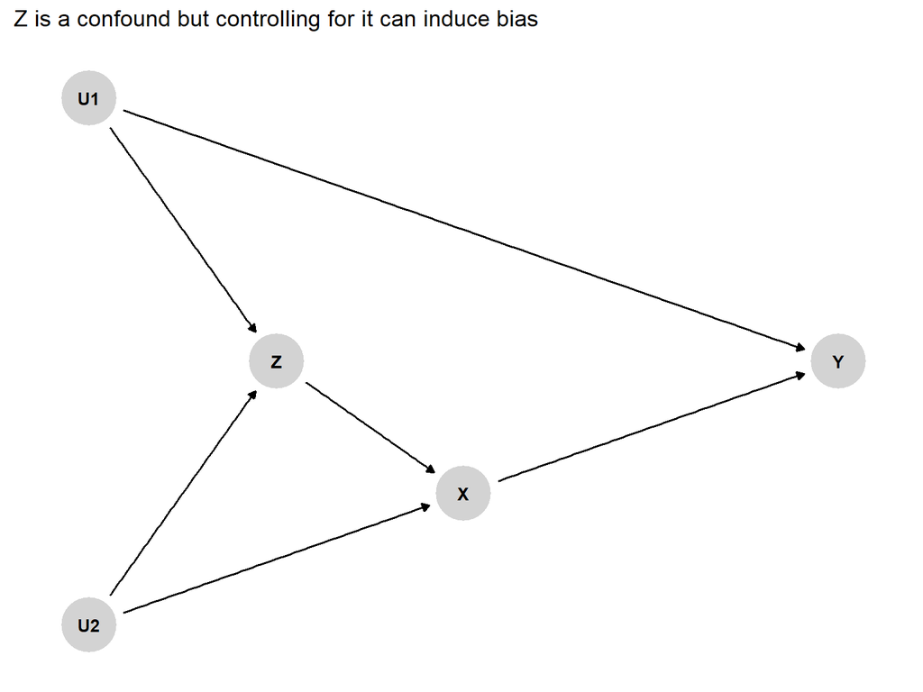

For a solution for a class of related problems see Robins, Hernan, and Brumback (2000)

### 4.6.9 Let’s look at that in dagitty

```r
g <- dagitty("dag{U1 -> Z  ; U1 -> y ;
             U2 -> Z ; U2 -> x  -> y;
             Z -> x}")
adjustmentSets(g, exposure = "x", outcome = "y")
```

```
{ U1 }
{ U2, Z }
```

which means you have to adjust on an unobservable. Here we double check that including or not including “Z” is enough:

```r
isAdjustmentSet(g, "Z", exposure = "x", outcome = "y")
```

```
[1] FALSE
```

```r
isAdjustmentSet(g, NULL, exposure = "x", outcome = "y")
```

```
[1] FALSE
```

### 4.6.10 Collider & Confounder

So we cannot *identify* the effect here. But can we still learn about it?

# 5 Frequentist Analysis

*Estimation and testing*

## 5.1 Outline

- Simple estimates from experimental data
- Weighting, blocking
- Design-based variance estimates
- Design-based $p$ values
- Controls and doubly robust estimation
- Reporting

### 5.1.1 ATE: DIM

Unbiased estimates of the (sample) average treatment effect can be estimated (**whether or not there imbalance on covariates**) using:

$$\widehat{ATE} = \frac{1}{n_T}\sum_TY_i - \frac{1}{n_C}\sum_CY_i,$$

### 5.1.2 ATE: DIM in practice

```r
df <- fabricatr::fabricate(N = 100, Z = rep(0:1, N/2), Y = rnorm(N) + Z)

# by hand
df |>
  summarize(Y1 = mean(Y[Z==1]),
            Y0 = mean(Y[Z==0]),
            diff = Y1 - Y0) |> kable(digits = 2)
```

| Y1 | Y0 | diff |
| --- | --- | --- |
| 1.07 | -0.28 | 1.35 |

```r
# with estimatr
estimatr::difference_in_means(Y ~ Z, data = df) |>
  tidy() |> kable(digits = 2)
```

| term | estimate | std.error | statistic | p.value | conf.low | conf.high | df | outcome |
| --- | --- | --- | --- | --- | --- | --- | --- | --- |
| Z | 1.35 | 0.17 | 7.94 | 0 | 1.01 | 1.68 | 97.98 | Y |

### 5.1.3 ATE: DIM in practice

We can also do this with regression:

```r
estimatr::lm_robust(Y ~ Z, data = df) |>
  tidy() |> kable(digits = 2)
```

| term | estimate | std.error | statistic | p.value | conf.low | conf.high | df | outcome |
| --- | --- | --- | --- | --- | --- | --- | --- | --- |
| (Intercept) | -0.28 | 0.12 | -2.33 | 0.02 | -0.51 | -0.04 | 98 | Y |
| Z | 1.35 | 0.17 | 7.94 | 0.00 | 1.01 | 1.68 | 98 | Y |

See Freedman (2008) on why regression is fine here

### 5.1.4 ATE: Blocks

Say now different strata or blocks $\mathcal{S}$ had different *assignment probabilities*. Then you could estimate:

$$\widehat{ATE} = \sum_{S\in \mathcal{S}}\frac{n_{S}}{n}
\left(\frac{1}{n_{S1}}\sum_{S\cap T}y_i - \frac{1}{n_{S0}}\sum_{S\cap C}y_i \right)$$

**Note**: you cannot just ignore the blocks because assignment is no longer independent of potential outcomes: you might be sampling units with different potential outcomes with different probabilities.

However, the formula above works fine because selecting is random *conditional* on blocks.

### 5.1.5 ATE: Blocks

As a DAG this is just classic confounding:

```r
make_model("Block -> Z ->Y <- Block") |>
  plot(x_coord = c(2,1,3), y_coord = c(2, 1, 1))
```

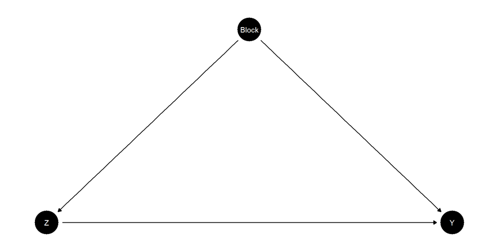

### 5.1.6 ATE: Blocks in practice

Data with heterogeneous assignments:

```r
df <- fabricatr::fabricate(
  N = 500, X = rep(0:1, N/2),
  prob = .2 + .3*X,
  Z = rbinom(N, 1, prob),
  ip = 1/(Z*prob + (1-Z)*(1-prob)), # discuss
  Y = rnorm(N) + Z*X)
```

True effect is 0.5, but:

```r
estimatr::difference_in_means(Y ~ Z, data = df) |>
  tidy() |> kable(digits = 2)
```

| term | estimate | std.error | statistic | p.value | conf.low | conf.high | df | outcome |
| --- | --- | --- | --- | --- | --- | --- | --- | --- |
| Z | 0.9 | 0.1 | 9.32 | 0 | 0.71 | 1.09 | 377.93 | Y |

### 5.1.7 ATE: Blocks in practice

Averaging over effects in blocks

```r
# by hand
estimates <-
  df |>
  group_by(X) |>
  summarize(Y1 = mean(Y[Z==1]),
            Y0 = mean(Y[Z==0]),
            diff = Y1 - Y0,
            W = n())

estimates$diff |> weighted.mean(estimates$W)
```

```
[1] 0.7236939
```

```r
# with estimatr
estimatr::difference_in_means(Y ~ Z, blocks = X, data = df) |>
  tidy() |> kable(digits = 2)
```

| term | estimate | std.error | statistic | p.value | conf.low | conf.high | df | outcome |
| --- | --- | --- | --- | --- | --- | --- | --- | --- |
| Z | 0.72 | 0.11 | 6.66 | 0 | 0.51 | 0.94 | 496 | Y |

### 5.1.8 ATE with IPW

This also corresponds to the difference in the weighted average of treatment outcomes (with weights given by the inverse of the probability that each unit is assigned to treatment) and control outcomes (with weights given by the inverse of the probability that each unit is assigned to control).

- The average difference in means estimator is the same as what you would get if you weighted inversely by shares of units in different conditions inside blocks.

### 5.1.9 ATE with IPW in practice

```r
# by hand
df |>
  summarize(Y1 = weighted.mean(Y[Z==1], ip[Z==1]),
            Y0 = weighted.mean(Y[Z==0],  ip[Z==0]), # note !
            diff = Y1 - Y0)|>
  kable(digits = 2)
```

| Y1 | Y0 | diff |
| --- | --- | --- |
| 0.59 | -0.15 | 0.74 |

```r
# with estimatr
estimatr::difference_in_means(Y ~ Z, weights = ip, data = df) |>
  tidy() |> kable(digits = 2)
```

| term | estimate | std.error | statistic | p.value | conf.low | conf.high | df | outcome |
| --- | --- | --- | --- | --- | --- | --- | --- | --- |
| Z | 0.74 | 0.11 | 6.65 | 0 | 0.52 | 0.96 | 498 | Y |

### 5.1.10 ATE with IPW

- But **inverse propensity weighting** is a more general principle, which can be used even if you do not have blocks.
- The intuition for it comes straight from **sampling weights** — you weight up in order to recover an unbiased estimate of the potential outcomes for all units, whether or not they are assigned to treatment.
- With sampling weights however you can include units even if their weight was 1. *Why can you not include these units when doing inverse propensity weighting?*

### 5.1.11 Illustration: Estimating treatment effects with terrible treatment assignments: Fixer

Say you made a mess and used a randomization that was correlated with some variable, $U$. For example:

- The randomization is done in a way that introduces a correlation between Treatment Assignment and Potential Outcomes
- Then possibly, even though there is no true causal effect, we naively estimate a large one — enormous bias
- However since we know the assignment procedure we can **fully** correct for the bias

### 5.1.12 Illustration: Estimating treatment effects with terrible treatment assignments: Fixer

- In the next example, we do this using “**inverse propensity score weighting**.”
- This is exactly analogous to standard survey weighting — since we selected different units for treatment with different probabilities, we weight them differently to recover the average outcome among treated units (same for control).

### 5.1.13 Basic randomization: Fixer

Bad assignment, some randomization process you can’t understand (but can replicate) that results in unequal probabilities.

```r
N <- 400
U <- runif(N, .1, .9)

 design <-
   declare_model(N = N,
                 Y_Z_0 = U + rnorm(N, 0, .1),
                 Y_Z_1 = U + rnorm(N, 0, .1),
                 Z = rbinom(N, 1, U)) +
  declare_measurement(Y = reveal_outcomes(Y ~ Z)) +
  declare_inquiry(ATE = mean(Y_Z_1 - Y_Z_0)) +
  declare_estimator(Y ~ Z, label = "naive")
```

### 5.1.14 Basic randomization: Fixer

Results is a sampling distribution not centered on the true effect (0)

```r
diagnosis <- diagnose_design(design)
```

```r
diagnosis$simulations_df |>
  ggplot(aes(estimate)) + geom_histogram() + facet_grid(~estimator) +
  geom_vline(xintercept = 0, color = "red")
```

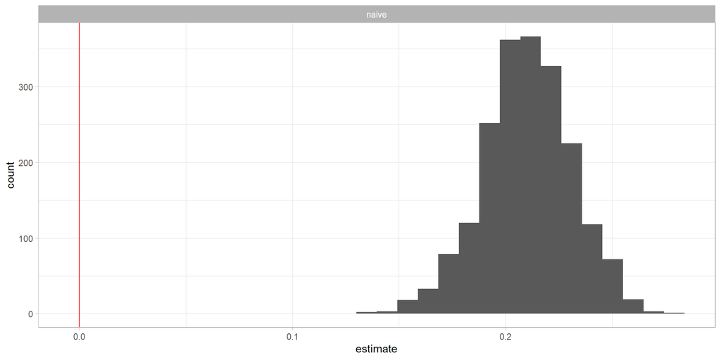

### 5.1.15 A fix

To fix you can estimate the assignment probabilities by replicating the assignment many times:

```r
probs <- replicate(1000, design |> draw_data() |> pull(Z)) |> apply(1, mean)
```

and then use these assignment probabilities in your estimator

```r
design_2 <-
  design +
  declare_measurement(weights = Z/probs + (1-Z)/(1-probs)) +
  declare_estimator(Y ~ Z, weights = weights, label = "smart")
```

### 5.1.16 Basic randomization: Fixer

Implied weights

```r
draw_data(design_2) |>
  ggplot(aes(probs, weights, color = factor(Z))) +
  geom_point()
```

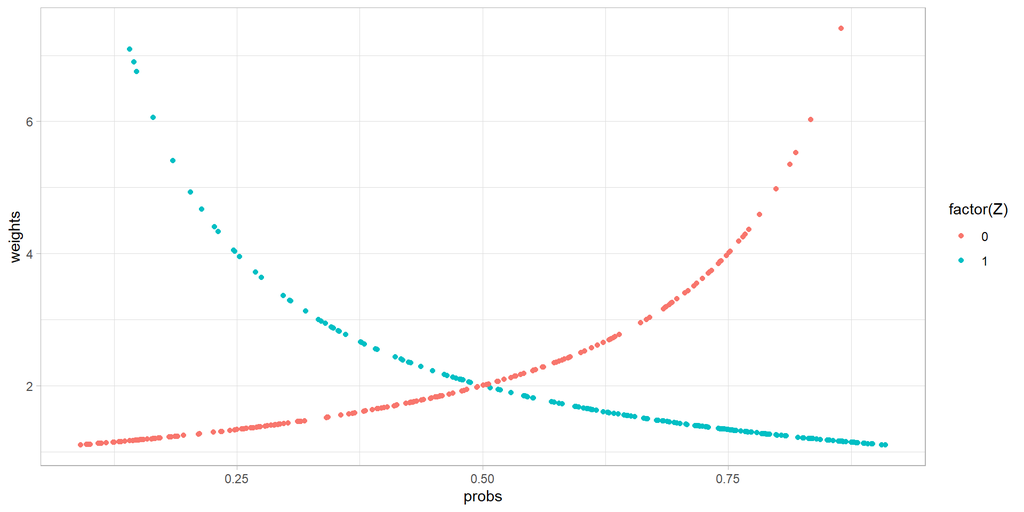

### 5.1.17 Basic randomization: Fixer

Improved results

```r
diagnosis <- diagnose_design(design_2)
```

```r
diagnosis$simulations_df |>
  ggplot(aes(estimate)) + geom_histogram() + facet_grid(estimator~.)+
  geom_vline(xintercept = 0, color = "red")
```

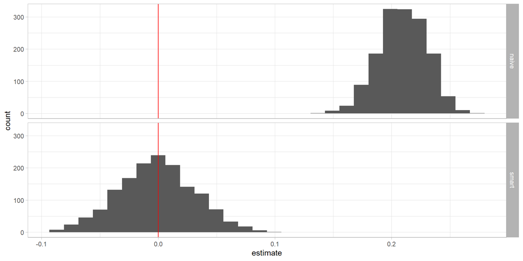

### 5.1.18 IPW with one unit!

This example is surprising but it helps you see the logic of why inverse weighting gets unbiased estimates (and why that might not guarantee a reasonable answer)

Imagine there is one unit with potential outcomes $Y(1) = 2, Y(0) = 1$. So the unit level treatment effect is 1.

You toss a coin.

- If you assign to treatment you estimate: $\hat\tau = \frac{2}{0.5} = 4$
- If you assign to control you estimate: $\hat\tau = -\frac{1}{0.5} = -2$

Great on average but *always* lousy

### 5.1.19 Generalization: why IPW works

- Say a given unit is assigned to treatment with probability $\pi_i$
- We estimate the average $Y(1)$ using

$$\hat{\overline{Y_1}} = \frac{1}n\left(\sum_i \frac{Z_iY_i(1)}{\pi_i}\right)$$
With independent assignment the expected value of $\hat{\overline{Y_1}}$ is just:

$$\mathbb{E}[\hat{\overline{Y_1}}] =\frac1n\left( \left(\pi_1 \frac{1\times Y_1(1)}{\pi_1} + (1-\pi_1) \frac{0\times Y_1(1)}{\pi_1}\right) + \left(\pi_2 \frac{1\times Y_2(1)}{\pi_2} + (1-\pi_2) \frac{0\times Y_1(1)}{\pi_2}\right) + \dots\right)$$

$$\mathbb{E}[\hat{\overline{Y_1}}] =\frac1n\left( Y_1(1) + Y_2(1) + \dots\right) = \overline{Y_1}$$

and similarly for $\mathbb{E}[\hat{\overline{Y_0}}]$ and so using linearity of expectations:

$$\mathbb{E}[\widehat{\overline{Y_1 - Y_0}}] = \overline{Y_1 - Y_0}$$

### 5.1.20 Generalization: why IPW works

- Note we needed $\pi_i >0$ and also $\pi_i <1$ everywhere. Why?
- We used independence here; sampling theory is used to show similar results for e.g. complete randomization
- For blocked randomization this is easy to see

## 5.2 Design-based Estimation of Variance

*Lets talk about “inference”*

### 5.2.1 Var(ATE)

- Recall that the treatment effect is gotten by taking a sample of outcomes under treatment and comparing them to a sample of outcomes under control
- Say that there is no “error”
- Why would this procedure produce uncertainty?

### 5.2.2 Var(ATE)

- Why would this procedure produce uncertainty?
- The uncertainty comes from being uncertain about the average outcome under control from observations of the control units, and from being uncertain about the average outcome under treatment from observation of the treated units
- In other words, it comes from the variance in the treatment outcomes and variance in the control outcomes (and not, for example, from variance in the treatment effect)

### 5.2.3 Var(ATE)

- In classical statistics we characterize our uncertainty over an estimate using an estimate of variance of the sampling distribution of the estimator.
- Key idea is we want to be able to say: how likely are we to have gotten such an estimate if the distribution of estimates associated with our design looked a given way.
- More specifically we want to estimate “standard error” or the “standard deviation of the sampling distribution”

(See [Woolridge (2023)](https://www.sciencedirect.com/science/article/pii/S0304407623002336) where the standard error is understood as the “*estimate* of the standard deviation of the sampling distribution”)

### 5.2.4 Variance and standard errors

Given:

- $\hat\tau$ is an estimate for $\tau$
- $\overline{x}$ is the average values of $x$

The variance of the estimator of $n$ repeated ‘runs’ of a design is: $Var(\hat{\tau}) = \frac{1}n\sum_i(\hat\tau_i - \overline{\hat\tau_i})^2$

And the standard error is:

$se(\hat{\tau}) = \sqrt{\frac{1}n\sum_i(\hat\tau_i - \overline{\hat\tau_i})^2}$

### 5.2.5 Variance and standard errors

If we have a good measure for the *shape* of the sampling distribution we can start to make statements of the form:

- What are the chances that an estimate would be this large or larger?

If the sampling distribution is roughly normal, as it may be with large samples, then we can use procedures such as: “there is a 5% probability that an estimate would be more than 1.96 standard errors away from the mean of the sampling distribution”

### 5.2.6 Var(ATE)

- **Key idea**: You can estimate variance straight from the data, given knowledge of the **assignment process** and assuming well defined potential outcomes?
- Recall in general $Var(x) = \frac{1}n\sum_i(x_i - \overline{x})^2$. here the $x_i$s are the treatment effect estimates we might get under different random assignments, the $n$ is number of different assignments (assumed here all equally likely, but otherwise we can weight) and $\overline{x}$ is the truth.
- For intuition imagine we have just two units $A$, $B$, with potential outcomes $A_1$, $A_0$, $B_1$, $B_0$.
- When there are two units with outcomes $x_1, x_2$, the variance simplifies like this:

$$Var(x) = \frac{1}2\left(x_1 - \frac{x_1 + x_2}{2}\right)^2 + \frac{1}2\left(x_2 - \frac{x_1 + x_2}{2}\right)^2 = \left(\frac{x_1 - x_2}{2}\right)^2$$

### 5.2.7 Var(ATE)

In the two unit case the two possible treatment estimates are: $\hat{\tau}_1=A_1 - B_0$ and $\hat{\tau}_2=B_1 - A_0$, depending on what gets put into treatment. So the variance is:

$$Var(\hat{\tau}) = \left(\frac{\hat{\tau}_1 - \hat{\tau}_2}{2}\right)^2 = \left(\frac{(A_1 - B_0) - (B_1 - A_0)}{2}\right)^2 =\left(\frac{(A_1 - B_1) + (A_0 - B_0)}{2}\right)^2$$
which we can re-write as:

$$Var(\hat{\tau}) = \left(\frac{A_1 - B_1}{2}\right)^2 + \left(\frac{A_0 - B_0}{2}\right)^2+ 2\frac{(A_1 - B_1)(A_0-B_0)}{2}$$
The first two terms correspond to the variance of $Y(1)$ and the variance of $Y(0)$. The last term is a bit pesky though, it corresponds to twice the *covariance* of $Y(1)$ and $Y(0)$.

### 5.2.8 Var(ATE)

How can we go about estimating this?

$$Var(\hat{\tau}) = \left(\frac{A_1 - B_1}{2}\right)^2 + \left(\frac{A_0 - B_0}{2}\right)^2+ 2\frac{(A_1 - B_1)(A_0-B_0)}{2}$$

In the two unit case it is quite challenging because we do not have an estimate for any of the three terms: we do not have an estimate for the variance in the treatment group or in the control group because we have only one observation in each case; and we do not have an estimate for the *covariance* because we don’t observe both potential outcomes for *any* case.

Things do look a bit better however with more units…

### 5.2.9 Var(ATE): Generalizing

From [Freedman Prop 1 / Example 1](http://www.stat.berkeley.edu/~census/neyregcm.pdf) (using combinatorics!) we have:

$V(\widehat{ATE}) = \frac{1}{n-1}\left[\frac{n_C}{n_T}V_1 + \frac{n_T}{n_C}V_0 + 2C_{01}\right]$

… where $V_0, V_1$ denote variances and $C_{01}$ covariance

This is usefully rewritten as:

$$\begin{split}
V(\widehat{ATE}) & = \frac{1}{n-1}\left[\frac{n - n_T}{n_T}V_1 + \frac{n - n_C}{n_C}V_0 + 2C_{01}\right] \\
& = \frac{n}{n-1}\left[\frac{V_1}{n_T} + \frac{V_0}{n_C}\right] - \frac{1}{n-1}\left[V_1 + V_0 - 2C_{01}\right]
\end{split}$$

where the final term is positive

### 5.2.11 ATE and Var(ATE)

For the case with blocking, the conservative estimator is:

$V(\widehat{ATE}) = {\sum_{S\in \mathcal{S}}{\left(\frac{n_{S}}{n}\right)^2} \left({\frac{s^2_{S1}}{n_{S1}}} + {\frac{s^2_{S0}}{n_{S0}}} \right)}$